# Station08 Annual Mean Temperature: Linear Trends, Structural Change and Bootstrap Inference

Station 08 — Computational Methods in Econometrics

# 1 Introduction and research question

Instrumental temperature records that begin in the eighteenth century are among the longest direct observations of near-surface climate. Estimating a trend from such a record requires more than fitting a straight line: residual autocorrelation, changing variance and changes in the trend itself all affect which statistical conclusions are valid. This report analyses the annual mean temperature record of Geneva (Station08) and addresses the question: *what does this record reveal about long-term warming, about the adequacy of a single linear trend, and about a possible change in the trend at an unknown date?*

Section 2 describes the data and their gap structure. Section 3 estimates a linear trend and examines its residuals, including a Monte Carlo Durbin–Watson test and a Breusch–Pagan test. Section 4 fits a continuous broken-trend model with an unknown break date, tests for the break with bootstrap procedures chosen in light of the Section 3 diagnostics, and constructs bootstrap confidence intervals for the pre- and post-break slopes. Section 5 evaluates the finite-sample size and power of these bootstrap procedures by simulation, and Section 6 concludes. All numbers quoted in the text are computed by the embedded code; executable consistency checks are collected in Appendix A.

# 2 Data and exploratory analysis

## 2.1 Station, data source and sample

The series is the Geneva station (Switzerland; 46.20°N, 6.15°E; elevation 405 m) from the Global Historical Climatology Network Monthly Temperature dataset, version 4, of the NOAA National Centers for Environmental Information (GHCN-M v4; Menne et al., 2018; DOI 10.7289/V5XW4GTH). Annual means are formed only for years with at least ten valid monthly values; the supplied file contains the calendar year and the annual mean temperature in °C.

We use the QCF series, i.e. the quality-controlled and homogenisation-adjusted version. This matters for interpretation. The pairwise homogenisation applied in GHCN-M v4 is designed to remove artificial level shifts caused by, for example, station relocations or instrument changes, so a change in trend detected in this series is less likely to be a documented measurement artefact. Adjustments for the earliest decades, however, rest on few neighbouring stations, and residual inhomogeneities cannot be ruled out with the information supplied.

The file contains 226 annual observations between 1753 and 2013. Since 261 calendar years lie in this range, 35 years are missing; they are located below. Apart from sorting by year and validating the file, no transformation is applied to the temperatures. The only transformation of the time variable is the rescaled index defined in Section 2.2.

```r
master_seed <- 20260926L
set.seed(master_seed)

library(ggplot2)

dat <- read.csv(file.path(project_root, "Station08.csv"))
stopifnot(identical(names(dat), c("Year", "Temperature")),
          nrow(dat) == 226L, !anyNA(dat),
          all(is.finite(dat$Year)), all(is.finite(dat$Temperature)),
          !anyDuplicated(dat$Year))

# Sort by year, validate supplied data instead of silently dropping observations.
dat <- dat[order(dat$Year), ]
stopifnot(all(diff(dat$Year)>0))
n <- nrow(dat)

cat("Number of observations n =", n, "\n")
```

```
## Number of observations n = 226
```

```r
cat("First year:", min(dat$Year), " Last year:", max(dat$Year), "\n")
```

```
## First year: 1753  Last year: 2013
```

## 2.2 Gap structure and time index

```r
# ---- Gap diagnostics: locate every "year jump" ----
full_years     <- seq(min(dat$Year), max(dat$Year))
missing_years  <- setdiff(full_years, dat$Year)
# year difference between consecutive observations
gap_len        <- diff(dat$Year)
# a difference > 1 indicates a gap
gap_start_idx  <- which(gap_len > 1)

gap_table <- data.frame(
  from      = dat$Year[gap_start_idx],
  to        = dat$Year[gap_start_idx + 1],
  n_missing = gap_len[gap_start_idx] - 1
)

print(gap_table)
```

```
##   from   to n_missing
## 1 1930 1932         1
## 2 1967 1969         1
## 3 1972 1976         3
## 4 1978 1980         1
## 5 1980 2010        29
```

```r
cat("\nTotal missing years:", length(missing_years), "\n")
```

```
##
## Total missing years: 35
```

```r
cat("Number of gaps:", nrow(gap_table), "\n")
```

```
## Number of gaps: 5
```

```r
big_gap <- gap_table[which.max(gap_table$n_missing), ]
cat("Largest gap:", big_gap$n_missing, "years, from", big_gap$from, "to", big_gap$to, "\n")
```

```
## Largest gap: 29 years, from 1980 to 2010
```

The record contains 5 gaps with a total of 35 missing years. Four gaps are short (one to three years) and lie between 1931 and 1979. The fifth spans 1981–2009, i.e. 29 consecutive years, and separates the last four observations (2010–2013) from the rest of the record. Observations that are adjacent in the data file are therefore not always adjacent in calendar time. We keep every supplied observation, use the actual calendar year as time regressor, and state for each diagnostic whether lags are counted in observation positions or in calendar years. In all time-series figures, lines connect only observations within the same run of consecutive years, so no line suggests data inside a gap.

**Time index.** The time regressor is
$$t_i = (\mathrm{Year}_i - 1850)/10 .$$
Dividing by ten expresses every slope in °C per decade. Centring at 1850 places the reference year next to the break date estimated in Section 4, which lies in the mid-nineteenth century. As a result, the intercept of the linear model is its fitted temperature in 1850, and the intercept of the broken-trend model is also its fitted temperature in 1850, since the estimated break occurs after this reference year. The two intercepts are therefore directly comparable at the same reference year. Centring is a reparametrisation: it changes only the intercept and leaves fitted values, residuals, slopes and every test statistic unchanged (Appendix C; verified numerically in Appendix A). The reference year was chosen after seeing the Section 4 estimate; it serves presentation only and carries no inferential weight.

```r
# Increment the segment id by 1 whenever the year jumps by more than 1 year; used to avoid drawing lines across gaps
dat$segment <- c(1, cumsum(diff(dat$Year) > 1) + 1)

# Centered, decade-scaled time index
dat$t <- (dat$Year - 1850) / 10
```

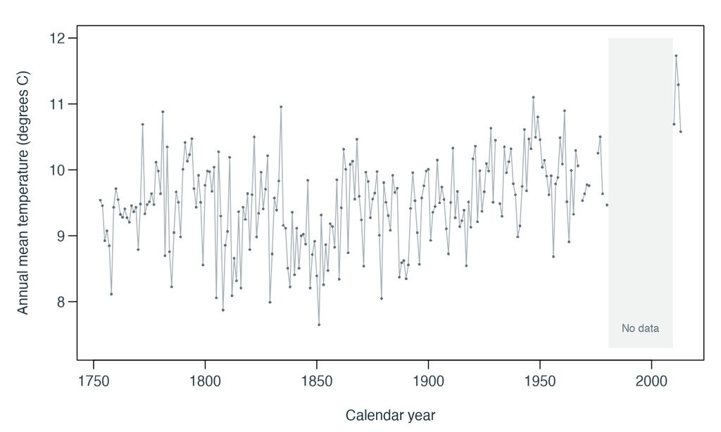

Observed annual temperatures at Station08. Lines connect consecutive calendar years only; shading marks the 1981-2009 gap.

```r
# Match the dimensions, font, margins and palette of the report's model-comparison plot.
# Use the validated observations directly; no fitted models or change-point marker.
draw_exploratory <- function() {
  par(mar = c(4.2, 4.5, 1.5, 1), mgp = c(2.7, .7, 0), las = 1,
      col.axis = axis_colour, col.lab = label_colour,
      col.main = label_colour, cex = .95)
  plot(dat$Year, dat$Temperature, type = "n",
       xlab = "Calendar year", ylab = "Annual mean temperature (degrees C)",
       ylim = c(7.3, 12))
  rect(1980.5, 7.3, 2009.5, 12, col = gap_fill, border = NA)
  for (ii in split(seq_len(nrow(dat)), dat$segment)) {
    lines(dat$Year[ii], dat$Temperature[ii], col = gray_line, lwd = 1)
  }
  points(dat$Year, dat$Temperature, pch = 16, cex = 0.42, col = gray)
  text(1995, 7.6, "No data", cex = 0.75, col = gray)
}

dir.create("figures", showWarnings = FALSE)
pdf(file.path("figures", "exploratory_series.pdf"), width = 8, height = 4.8,
    family = "Helvetica", useDingbats = FALSE)
draw_exploratory()
invisible(dev.off())
png(file.path("figures", "exploratory_series.png"), width = 8 * 180,
    height = 4.8 * 180, res = 180, type = "cairo")
draw_exploratory()
invisible(dev.off())

knitr::include_graphics(file.path(artifact_root, "figures/exploratory_series.png"))
```

## 2.3 Exploratory analysis

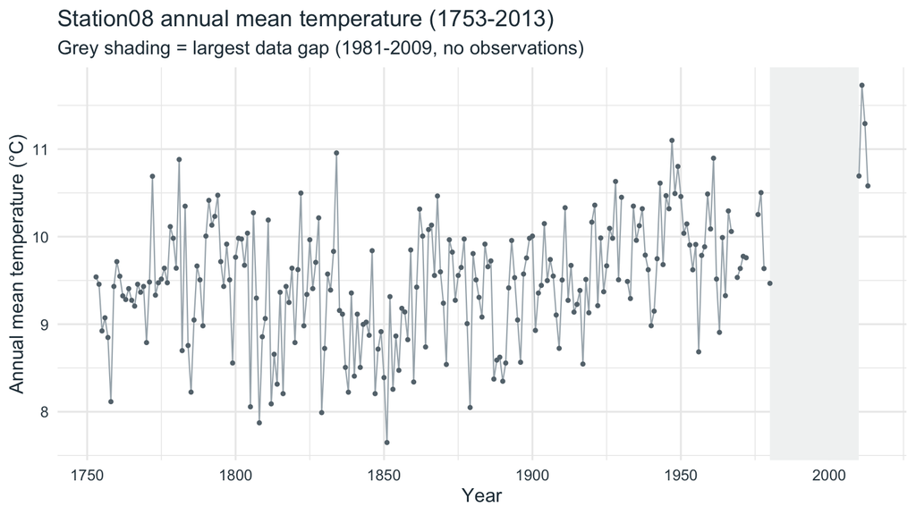

Annual mean temperature at Geneva, 1753–2013 (°C). Lines connect consecutive years only; the shaded band marks the 1981–2009 period without observations.

```r
ggplot(dat, aes(x = Year, y = Temperature)) +
  annotate("rect", xmin = big_gap$from, xmax = big_gap$to,
           ymin = -Inf, ymax = Inf, fill = gap_fill) +
  geom_line(aes(group = segment), linewidth = 0.4, colour = gray_line) +
  geom_point(size = 0.8, colour = gray) +
  labs(
    title = "Station08 annual mean temperature (1753-2013)",
    subtitle = "Grey shading = largest data gap (1981-2009, no observations)",
    x = "Year", y = "Annual mean temperature (°C)"
  ) +
  theme_minimal(base_size = 12) +
  theme(text = element_text(colour = label_colour),
        axis.text = element_text(colour = axis_colour))
```

```r
cat("Temperature range:", round(range(dat$Temperature), 2), "\n")
```

```
## Temperature range: 7.65 11.73
```

```r
cat("5 coldest years:\n")
```

```
## 5 coldest years:
```

```r
print(head(dat[order(dat$Temperature), c("Year", "Temperature")], 5))
```

```
##     Year Temperature
## 99  1851    7.648333
## 56  1808    7.873333
## 77  1829    7.990000
## 127 1879    8.048333
## 53  1805    8.056667
```

```r
cat("5 warmest years:\n")
```

```
## 5 warmest years:
```

```r
print(tail(dat[order(dat$Temperature), c("Year", "Temperature")], 5))
```

```
##     Year Temperature
## 208 1961    10.89667
## 82  1834    10.95667
## 194 1947    11.10000
## 225 2012    11.29167
## 224 2011    11.73000
```

```r
cat("Standard deviation before 1900:", round(sd(dat$Temperature[dat$Year < 1900]), 3),
    "  Standard deviation from 1900 onward:", round(sd(dat$Temperature[dat$Year >= 1900]), 3), "\n")
```

```
## Standard deviation before 1900: 0.665   Standard deviation from 1900 onward: 0.61
```

The figure above shows the series. Its main empirical features are the following.

**Direction of the trend.** The record does not rise uniformly. Mean temperature is 9.49 °C before 1800, 9.20 °C in 1800–1849, 9.26 °C in 1850–1899 and 9.79 °C in 1900–1980. The series thus drifts downward from the late eighteenth into the mid-nineteenth century and rises mainly during the twentieth century. All four observations after the long gap rank among the twelve warmest years of the record. A single straight line through this record averages an early flat-to-cooling phase with later warming, which motivates the broken-trend analysis of Section 4.

**Interannual variability.** The sample standard deviation is 0.70 °C, and year-to-year changes are large relative to the long-run movements described above. The standard deviation is 0.665 °C before 1900 and 0.610 °C from 1900 onwards. These raw figures also contain trend movements within each sub-period, so they indicate only that variability has not visibly increased; Section 3 assesses changing variance formally.

**Unusual observations.** The coldest year is 1851 (7.65 °C) and the warmest is 2011 (11.73 °C). No observation is removed. The coldest year lies in the same period as the break date estimated in Section 4, which therefore checks how sensitive the estimated break is to this single year.

**Missing decades.** The 2010–2013 observations follow 29 years without data. They cannot show whether warming during that interval was gradual, accelerating or interrupted, and we do not interpret the difference between 1980 and 2010 as a discontinuity.

# 3 Linear trend and model diagnostics

We first examine whether a single linear trend is an adequate initial description of the series. This section concentrates on estimation, interpretation and diagnostics; the statistical significance of the trend is not assessed here. The model is
$$y_i=\beta_0 + \beta_1 t_i + \varepsilon_i, \qquad
i=1,\ldots,n,$$
where $y_i$ is the annual mean temperature of the $i$-th observation, $i$ indexes observation positions, and $t_i=(\mathrm{Year}_i-1850)/10$ is the calendar-time index of Section 2.2. Hence $\beta_0$ is the fitted temperature in 1850 and $\beta_1$ is the trend in °C per decade.

## 3.1 OLS estimation of the linear trend

```r
trend_model <- lm(Temperature ~ t, data = dat)
summary(trend_model)
```

```
##
## Call:
## lm(formula = Temperature ~ t, data = dat)
##
## Residuals:
##      Min       1Q   Median       3Q      Max
## -1.80313 -0.42453  0.04061  0.42563  1.73919
##
## Coefficients:
##             Estimate Std. Error t value Pr(>|t|)
## (Intercept) 9.448087   0.045176 209.139  < 2e-16 ***
## t           0.033709   0.006563   5.136 6.09e-07 ***
## ---
## Signif. codes:  0 '***' 0.001 '**' 0.01 '*' 0.05 '.' 0.1 ' ' 1
##
## Residual standard error: 0.6596 on 224 degrees of freedom
## Multiple R-squared:  0.1054, Adjusted R-squared:  0.1014
## F-statistic: 26.38 on 1 and 224 DF,  p-value: 6.086e-07
```

```r
print(coef(trend_model))
```

```
## (Intercept)           t
##  9.44808746  0.03370928
```

```r
cat("R-squared:", round(summary(trend_model)$r.squared, 4), "\n")
```

```
## R-squared: 0.1054
```

```r
beta0_hat <- coef(trend_model)[1]
beta1_hat <- coef(trend_model)[2]

cat("Estimated intercept (fitted temperature in 1850):", round(beta0_hat, 3), "°C\n")
```

```
## Estimated intercept (fitted temperature in 1850): 9.448 °C
```

```r
cat("Estimated slope:", round(beta1_hat, 4), "°C per decade\n")
```

```
## Estimated slope: 0.0337 °C per decade
```

```r
cat("Converted to per century:", round(beta1_hat * 10, 3), "°C per century\n")
```

```
## Converted to per century: 0.337 °C per century
```

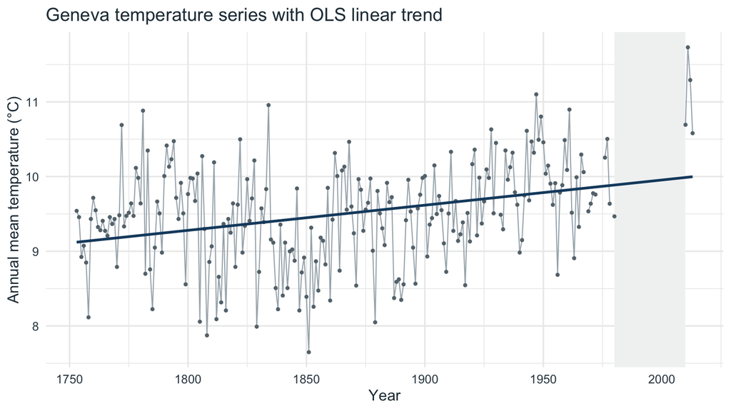

Annual mean temperature (grey) with the OLS linear trend (navy), °C. The shaded band marks the 1981–2009 gap.

```r
dat$fitted_linear <- fitted(trend_model)

ggplot(dat, aes(x = Year, y = Temperature)) +
  annotate("rect", xmin = big_gap$from, xmax = big_gap$to,
           ymin = -Inf, ymax = Inf, fill = gap_fill) +
  geom_line(aes(group = segment), linewidth = 0.4, colour = gray_line) +
  geom_point(size = 0.8, colour = gray) +
  geom_line(aes(y = fitted_linear), colour = navy, linewidth = 1) +
  labs(title = "Geneva temperature series with OLS linear trend",
       x = "Year", y = "Annual mean temperature (°C)") +
  theme_minimal(base_size = 12) +
  theme(text = element_text(colour = label_colour),
        axis.text = element_text(colour = axis_colour))
```

**Interpretation.** The estimated intercept, $\hat\beta_0=$ 9.448 °C, is the temperature implied by the fitted line in 1850. The estimated slope, $\hat\beta_1=$ 0.0337 °C per decade (0.337 °C per century), is the average linear change over the observed record. The trend explains only a small share of the total variation ($R^2=$ 0.105), consistent with the exploratory finding that interannual variability dominates the long-run change.

**Effect of the gaps.** Because the regressor is calendar time, the slope keeps its meaning under unequal spacing, and OLS is well defined for this fixed design. The gaps nevertheless determine which periods are represented and therefore affect the estimate and its precision. The 222 observations up to 1980 inform the slope as well; it is not determined solely by a contrast between the four post-gap values and the rest. A single slope says nothing about the path of temperature inside the missing decades, and neither the exogeneity of the errors nor the mechanism behind the missing years can be verified from the supplied file. In line with the research design, no significance statement about $\beta_1$ is made at this stage.

## 3.2 Residual diagnostics

```r
dat$residual    <- residuals(trend_model)
dat$residual_sq <- dat$residual^2
```

### 3.2.1 Residuals over time

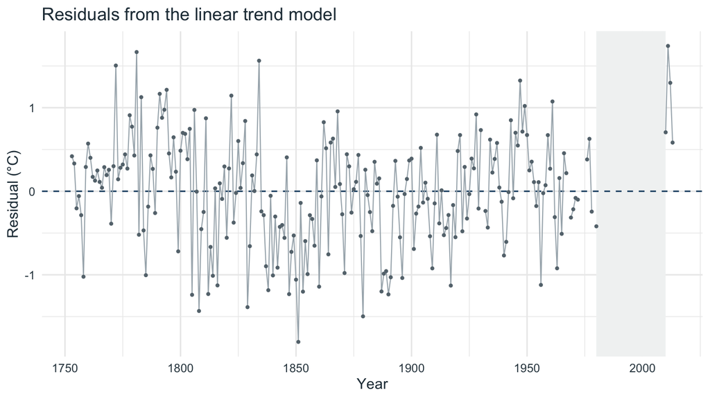

Residuals of the linear trend model against calendar year (°C). Lines connect consecutive years only; the shaded band marks the 1981–2009 gap.

```r
ggplot(dat, aes(x = Year, y = residual)) +
  annotate("rect", xmin = big_gap$from, xmax = big_gap$to,
           ymin = -Inf, ymax = Inf, fill = gap_fill) +
  geom_hline(yintercept = 0, linetype = "dashed", colour = navy) +
  geom_line(aes(group = segment), linewidth = 0.4, colour = gray_line) +
  geom_point(size = 0.8, colour = gray) +
  labs(title = "Residuals from the linear trend model", x = "Year", y = "Residual (°C)") +
  theme_minimal(base_size = 12) +
  theme(text = element_text(colour = label_colour),
        axis.text = element_text(colour = axis_colour))
```

The residuals fluctuate around zero, with runs of similarly signed values and low-frequency departures from the linear fit. These patterns suggest residual dependence and possible inadequacy of the constant-trend mean. We inspect both observation-lag and calendar-lag ACFs, then calibrate the Durbin–Watson statistic by Monte Carlo simulation.

### 3.2.2 Residual autocorrelation by observation and calendar lag

**Why the lag definition matters:** Applied to the observed residual vector, `acf()` measures lag by row position. It is a valid description of dependence between observed rows, but a one-observation lag is not always a one-calendar-year lag. For example, observations 222 and 223 correspond to 1980 and 2010, thirty calendar years apart.

**Calendar-lag comparison:** Place residuals on the full calendar grid, insert `NA` for unobserved years, and use `na.action = na.pass`. This uses available pairs for each calendar lag without imputing temperatures. With missing values, the resulting estimates need not define a valid autocorrelation sequence; the usual plot bounds are descriptive rather than calibrated inference. Both ACFs are retained, and their lag meanings are stated explicitly.

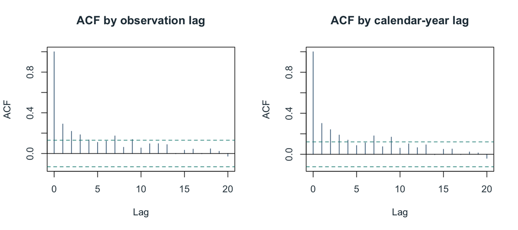

Sample autocorrelation of the linear-trend residuals by observation lag (left) and by calendar-year lag with missing years set to NA (right).

```r
# Naive approach (uncorrected, shown only for comparison to illustrate the problem)
acf_naive <- acf(dat$residual, lag.max = 20, plot = FALSE)

# Corrected approach: place back on the full calendar grid + na.action = na.pass
res_full <- rep(NA_real_, length(full_years))
res_full[match(dat$Year, full_years)] <- dat$residual
res_ts   <- ts(res_full, start = min(full_years), frequency = 1)
acf_gap  <- acf(res_ts, na.action = na.pass, lag.max = 20, plot = FALSE)

par(mfrow = c(1, 2), col.axis = axis_colour, col.lab = label_colour,
    col.main = label_colour)
plot(acf_naive, main = "ACF by observation lag", col = navy, ci.col = teal)
plot(acf_gap,   main = "ACF by calendar-year lag", col = navy, ci.col = teal)
```

```r
cat("Observation-lag 1 autocorrelation:", round(acf_naive$acf[2], 3), "\n")
```

```
## Observation-lag 1 autocorrelation: 0.29
```

```r
cat("Calendar-lag 1 autocorrelation:", round(acf_gap$acf[2], 3), "\n")
```

```
## Calendar-lag 1 autocorrelation: 0.302
```

```r
par(mfrow = c(1, 1))
```

The first observation-lag and calendar-lag autocorrelations are 0.290 and 0.302. They are close here because most observed pairs are consecutive calendar years. Both indicate positive short-range residual dependence. Their similarity in this dataset does not make the two lag definitions interchangeable in general.

### 3.2.3 Residual variance over time

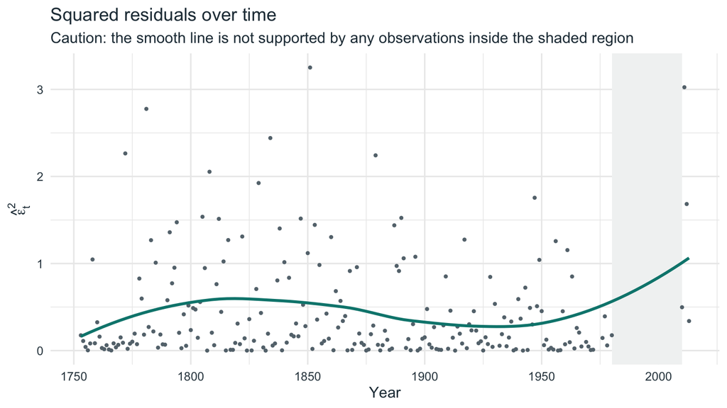

Squared residuals of the linear trend model (°C²) against calendar year, with a descriptive loess smooth. The shaded band marks the 1981–2009 gap.

```r
ggplot(dat, aes(x = Year, y = residual_sq)) +
  annotate("rect", xmin = big_gap$from, xmax = big_gap$to,
           ymin = -Inf, ymax = Inf, fill = gap_fill) +
  geom_point(size = 0.8, colour = gray) +
  geom_smooth(method = "loess", se = FALSE, colour = teal) +
  labs(
    title = "Squared residuals over time",
    subtitle = "Caution: the smooth line is not supported by any observations inside the shaded region",
    x = "Year", y = expression(hat(epsilon)[t]^2)
  ) +
  theme_minimal(base_size = 12) +
  theme(text = element_text(colour = label_colour),
        axis.text = element_text(colour = axis_colour))
```

The scatter uses actual calendar years. The loess curve is a descriptive smooth, and its portion inside the long gap is not supported by observations from those years. The final four observations can influence its endpoint behavior; the plot cannot establish how variance evolved during the gap. No formal conclusion about constant variance follows from this smooth alone.

### 3.2.4 Normal QQ plot

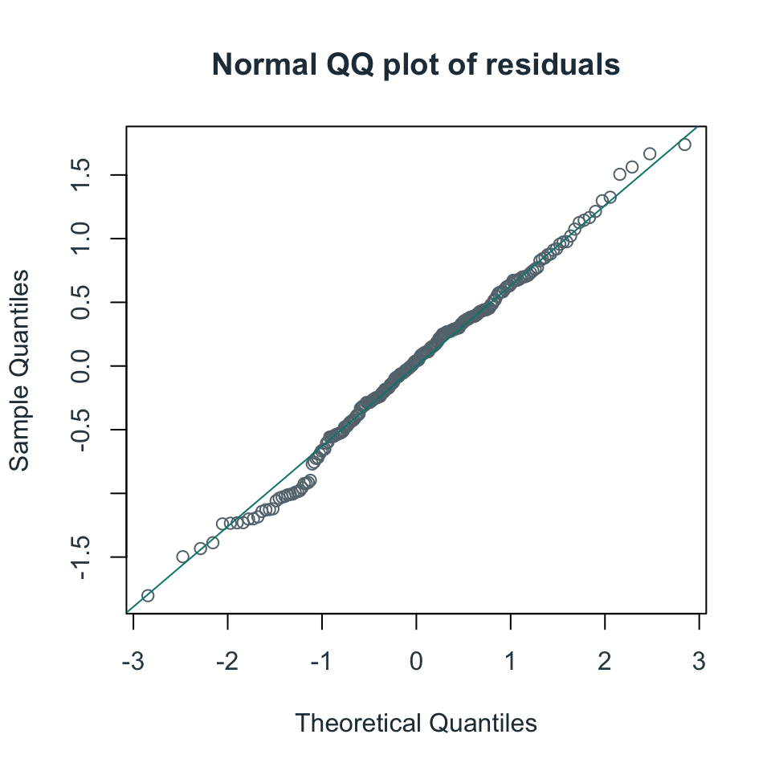

Normal QQ plot of the linear-trend residuals (°C).

```r
par(col.axis = axis_colour, col.lab = label_colour, col.main = label_colour)
qqnorm(dat$residual, main = "Normal QQ plot of residuals", col = gray)
qqline(dat$residual, col = teal)
```

The QQ plot is broadly linear in its center, with some tail departures. This is compatible with a Gaussian approximation but does not verify normality. Time spacing does not enter the QQ construction, although the plotted marginal distribution still reflects only the observed years. Gaussian errors remain an explicit reference assumption for the DW Monte Carlo calibration.

## 3.3 Monte Carlo Durbin–Watson test for first-order autocorrelation

**Primary statistic.** The research design specifies the Durbin–Watson statistic.

$$d=\frac{\sum_{i=2}^n(\widehat
e_i-\widehat e_{i-1})^2}{\sum_{i=1}^n\widehat e_i^2}.$$

Adjacency in its numerator is by observation position. We implement this definition as the primary test and interpret it accordingly. Calendar gaps affect its meaning, but restricting the numerator to calendar-adjacent pairs would define a different statistic rather than implement the specified one.

**Calendar-adjacency sensitivity.** As a sensitivity check we also compute

$$d_{\mathrm{calendar}}=\frac{\sum_{i:\
s_{i+1}-s_i=1}(\widehat e_{i+1}-\widehat e_i)^2}{\sum_i\widehat
e_i^2},$$

where $s_i$ is the calendar year of observation $i$. It uses only pairs of genuinely consecutive years. Both statistics can be written as $e'Ae/e'e$ with different difference matrices $A$, and each is calibrated with its own formula under the same observed regression design.

```r
# Naive DW (uncorrected, shown only for comparison)
dw_naive_stat <- function(e) sum(diff(e)^2) / sum(e^2)
d_obs_naive <- dw_naive_stat(dat$residual)

# ---- Gap-sensitive DW: only compute differences over pairs that are truly calendar-adjacent (year difference = 1) ----
valid_pairs <- which(diff(dat$Year) == 1)      # indices of valid "adjacent pairs"
m_pairs <- length(valid_pairs)

Dmat <- matrix(0, nrow = m_pairs, ncol = n)
for (k in seq_len(m_pairs)) {
  i <- valid_pairs[k]
  Dmat[k, i]     <- -1
  Dmat[k, i + 1] <-  1
}
A_gap <- crossprod(Dmat)   # A = D'D

dw_gap_stat <- function(e) as.numeric((t(e) %*% A_gap %*% e) / (t(e) %*% e))
d_obs_gap <- dw_gap_stat(dat$residual)
d_obs <- d_obs_naive  # primary statistic: assignment definition

cat("Assigned observation-adjacency DW:", round(d_obs_naive, 4), "\n")
```

```
## Assigned observation-adjacency DW: 1.4147
```

```r
cat("Gap-sensitive DW statistic:", round(d_obs_gap, 4), "\n")
```

```
## Gap-sensitive DW statistic: 1.3865
```

```r
cat("Valid calendar-adjacent year pairs used:", m_pairs, "/", n - 1, "sequence-adjacent pairs\n")
```

```
## Valid calendar-adjacent year pairs used: 220 / 225 sequence-adjacent pairs
```

The primary statistic is 1.4147, and the calendar-adjacency variant is 1.3865. There are 220 calendar-adjacent pairs among the 225 observation-adjacent pairs. Both are reported; the primary statistic governs the conclusion of this section.

### 3.3.1 Design of the Monte Carlo test

Under the null hypothesis $\varepsilon\sim N(0,\sigma^2 I_n)$, the OLS residuals are $e=M_X\varepsilon$ with $M_X=I-X(X'X)^{-1}X'$. The projection removes the regression coefficients, and because $d=e'Ae/e'e$ is a ratio of quadratic forms in $e$, the error variance cancels. The null distribution of $d$ therefore depends only on the known design matrix $X$ and the difference matrix $A$: $d$ is *pivotal* under this null, and its exact finite-sample distribution can be simulated to any desired precision.

The test proceeds as follows. For $b=1,\ldots,B$ with $B=9{,}999$, draw $\varepsilon^{*}_b\sim N(0,I_n)$, form $e^*_b=M_X\varepsilon^*_b$, and evaluate both DW definitions on $e^*_b$. Because the null distribution of $d$ need not be symmetric around two, the two tails are calibrated separately: the lower and upper critical values $c_L$ and $c_U$ are the empirical 2.5% and 97.5% quantiles of the simulated statistics (R’s type-6 quantile), not one quantile reflected around two. The **rejection region** of the two-sided 5% test is therefore
$$\mathcal
R=\{d<c_L\}\cup\{d>c_U\},$$
two tails that need not be equally far from two. Values in the lower tail indicate positive first-order autocorrelation; values in the upper tail indicate negative autocorrelation. The two-sided Monte Carlo p-value is
$$p=\min\Bigl\{1,\;2\min\Bigl(\tfrac{1+\#\{d^*_b\le
d\}}{B+1},\;\tfrac{1+\#\{d^*_b\ge d\}}{B+1}\Bigr)\Bigr\}.$$
With $B=9{,}999$, the type-6 cutoffs are the 250th and 9,750th ordered simulated statistics. Under the continuous null, strict rejection outside these cutoffs agrees with $p\le0.05$. This rank rule has exact 5% size under the iid Gaussian null, although the simulated cutoffs and p-value vary across simulation runs. It is not a test of the broader null of every process without first-order correlation, and non-Gaussian errors would change the reference distribution.

```r
X <- model.matrix(trend_model)
H <- X %*% solve(t(X) %*% X) %*% t(X)
M <- diag(n) - H

set.seed(master_seed)
B <- 9999L
d_sim <- d_sim_gap <- numeric(B)

for (b in seq_len(B)) {
  eps_star <- rnorm(n)
  e_star <- as.numeric(M %*% eps_star)
  d_sim[b] <- dw_naive_stat(e_star)   # assigned observation-adjacency statistic
  d_sim_gap[b] <- dw_gap_stat(e_star) # retained calendar-adjacent sensitivity
}

alpha <- 0.05
crit_lower <- unname(quantile(d_sim, alpha / 2, type = 6))
crit_upper <- unname(quantile(d_sim, 1 - alpha / 2, type = 6))
p_lower_adj <- (sum(d_sim <= d_obs) + 1) / (B + 1)
p_upper_adj <- (sum(d_sim >= d_obs) + 1) / (B + 1)
p_val_dw <- min(1, 2 * min(p_lower_adj, p_upper_adj))

crit_gap <- unname(quantile(d_sim_gap, c(alpha / 2, 1 - alpha / 2), type = 6))
p_val_dw_gap <- min(1, 2 * min(
  (sum(d_sim_gap <= d_obs_gap) + 1) / (B + 1),
  (sum(d_sim_gap >= d_obs_gap) + 1) / (B + 1)
))
dw_results <- data.frame(
  Definition = c("Assigned: observation adjacency", "Sensitivity: calendar adjacency"),
  Statistic = c(d_obs, d_obs_gap),
  Lower_2_5_percent = c(crit_lower, crit_gap[1]),
  Upper_97_5_percent = c(crit_upper, crit_gap[2]),
  Equal_tail_p_value = c(p_val_dw, p_val_dw_gap)
)
knitr::kable(dw_results, digits = 4)
```

| Definition | Statistic | Lower_2_5_percent | Upper_97_5_percent | Equal_tail_p_value |
| --- | --- | --- | --- | --- |
| Assigned: observation adjacency | 1.4147 | 1.7549 | 2.2695 | 2e-04 |
| Sensitivity: calendar adjacency | 1.3865 | 1.7106 | 2.2211 | 2e-04 |

```r
# Optional packaged cross-check uses its own statistic/reference and is not the primary calibration.
if (requireNamespace("lmtest", quietly = TRUE)) {
  print(lmtest::dwtest(trend_model, alternative = "two.sided"))
}
```

```
##
##  Durbin-Watson test
##
## data:  trend_model
## DW = 1.4147, p-value = 7.232e-06
## alternative hypothesis: true autocorrelation is not 0
```

**Result.** The observed statistic is $d=$ 1.4147, with Monte Carlo critical values $c_L=$ 1.7549 and $c_U=$ 2.2695 and two-sided p-value 0.0002. The statistic lies in the lower tail of the rejection region, so the null of no first-order autocorrelation is rejected at the 5% level in the direction of positive autocorrelation. The calendar-adjacency variant gives p = 0.0002 and also indicates positive dependence. These results agree with the residual plot and both ACFs. A rejection means that the independent Gaussian errors of the linear model are not supported; it does not identify the cause, and a misspecified mean, such as an unmodelled change in slope, can also produce autocorrelated residuals.

## 3.4 Breusch–Pagan test for heteroskedasticity

The auxiliary regression

$$\widehat
e_i^2=\gamma_0+\gamma_1t_i+v_i$$

tests for a **linear variance trend**, using the requested statistic $BP=nR^2$ and nominal $\chi^2_1$ reference. A zero time coefficient is a narrow diagnostic null; non-rejection does not establish homoskedasticity against every possible variance pattern.

**On gaps and calibration:** The regression uses actual transformed calendar year and does not require equally spaced rows for its algebra. Missing periods still limit interpretation, and the detected residual dependence weakens the usual asymptotic chi-square reference. This limitation is separate from the choice of observation versus calendar adjacency in DW and ACF.

```r
aux_model <- lm(residual_sq ~ t, data = dat)
R2_aux   <- summary(aux_model)$r.squared
BP_stat  <- n * R2_aux
p_val_bp <- pchisq(BP_stat, df = 1, lower.tail = FALSE)

cat("Breusch-Pagan statistic BP:", round(BP_stat, 4), "\n")
```

```
## Breusch-Pagan statistic BP: 0.4173
```

```r
cat("Degrees of freedom:", 1, "\n")
```

```
## Degrees of freedom: 1
```

```r
cat("BP p-value:", round(p_val_bp, 4), "\n")
```

```
## BP p-value: 0.5183
```

```r
# Previous cross-check: bptest(trend_model, varformula = ~ t, data = dat)
# Optional cross-check; no dependency on lmtest for the main result.
if (requireNamespace("lmtest", quietly = TRUE)) {
  print(lmtest::bptest(trend_model, varformula = ~ t, data = dat))
}
```

```
##
##  studentized Breusch-Pagan test
##
## data:  trend_model
## BP = 0.41731, df = 1, p-value = 0.5183
```

**Result.** $BP=$ 0.4173 with nominal $\chi^2_1$ p-value 0.5183. Homoskedasticity is not rejected at the 5% level: there is no evidence of a linear trend in the residual variance. This is consistent with the variance plot. Non-rejection does not establish constant variance, because the test is directed at one specific alternative and its asymptotic reference distribution is affected by the residual dependence found above.

## 3.5 Comparing the inferential principles

A Monte Carlo test requires a statistic whose null distribution can be simulated without knowing any unknown parameter, i.e. a statistic that is pivotal under the null hypothesis being tested.

**Durbin–Watson.** The null hypothesis is fully specified up to $(\beta,\sigma^2)$: independent $N(0,\sigma^2)$ errors. As shown above, $\beta$ disappears through the projection $M_X$ and $\sigma^2$ cancels in the ratio $e'Ae/e'e$. The null distribution of $d$ is therefore the same for every admissible parameter value and depends only on the known $X$. Simulating standard-normal errors reproduces it, and the Monte Carlo rank test has exact 5% size for the replication count and rejection rule used here (Dufour and Khalaf, 2001). This exactness is conditional on normality: if the errors were independent but non-Gaussian, the simulated reference distribution would only be an approximation.

**Breusch–Pagan.** The null of interest is homoskedasticity, $\operatorname{Var}(\varepsilon_i)=\sigma^2$ for all $i$, and it does not specify the error distribution. The statistic $BP=nR^2$ is scale-invariant, so $\sigma^2$ still cancels. Its finite-sample distribution, however, depends on the shape of the error distribution, in particular on its kurtosis, because the auxiliary regression is fitted to squared residuals whose variability is governed by the fourth moment. The kurtosis is a nuisance parameter left unrestricted by the homoskedasticity null, so $BP$ is not pivotal under that null. One could simulate $BP$ under iid Gaussian errors, giving a finite-sample reference distribution for that specific null. Applying those critical values to homoskedastic errors with other distributions or serial dependence can distort size. The $nR^2$ form used here is Koenker’s (1981) studentised version of the Breusch and Pagan (1979) test, whose *asymptotic* $\chi^2_1$ distribution holds without normality; this is why the test relies on the asymptotic reference rather than on a simulated finite-sample distribution.

We therefore retain the asymptotic calibration and qualify its conclusion in light of the residual dependence, rather than treating non-rejection as proof of constant variance.

## 3.6 Overall assessment of the initial model

Bringing the graphical and formal diagnostics together:

1. **Positive descriptive slope.** The full-sample linear estimate is 0.0337 °C per decade, with $R^2=$ 0.105. This is a modest average fitted change, not a statement about statistical significance.
2. **Gaussian reference remains an assumption.** The QQ plot is broadly linear in its centre with tail departures; it does not verify normality.
3. **No detected linear variance trend.** The nominal BP p-value is 0.5183. Non-rejection does not establish homoskedasticity, and dependence qualifies the reference distribution.
4. **Residual dependence matters.** Both DW variants and both ACFs indicate positive residual dependence. Conventional OLS standard errors that assume independent errors are therefore not a reliable basis for inference. A richer mean specification may reduce, but need not eliminate, this pattern.
5. **Missing periods constrain interpretation.** Actual calendar spacing is retained, but there is no direct evidence about temperatures during 1981–2009, and the missingness mechanism and detailed station history are unknown.

**Conclusion.** The linear model is a useful starting description but not an adequate final one. Its residual patterns motivate a model in which the slope may change, and the detected dependence requires inference that does not assume independent errors. Sections 4 and 5 carry out that inference and evaluate its finite-sample behaviour.

# 4 Structural change and bootstrap inference

This section asks whether the temperature trend changed at an unknown date. We fit a continuous broken-trend model, estimate the break date by least squares over a trimmed set of candidate dates, test the no-break null with bootstrap procedures selected on the basis of the Section 3 diagnostics, and construct bootstrap confidence intervals for the pre- and post-break slopes.

```r
year <- dat$Year
y <- dat$Temperature
x <- dat$t
m0 <- trend_model
e0 <- dat$residual
seed <- master_seed
B_test <- 9999L
B_ci <- 4999L
B_dw <- B
simulation_M <- 1000L
simulation_B <- 499L
dw <- d_obs
dwcrit <- c(crit_lower, crit_upper)
dwp<-p_val_dw
bp<- BP_stat
bpp <- p_val_bp
ncores<- parallel::detectCores()
if (is.na(ncores)) ncores <- 1L
stopifnot(is.logical(params$recompute_simulation),
          length(params$recompute_simulation) == 1L,
          !is.na(params$recompute_simulation),
          is.numeric(params$workers), length(params$workers) == 1L,
          is.finite(params$workers), params$workers >= 1)
workers <- min(as.integer(params$workers), ncores)
```

```r
plot_pair <-function(name, draw,width = 8, height = 4.8) {
  pdf(file.path("figures", paste0(name, ".pdf")), width = width, height=height, family="Helvetica", useDingbats=FALSE)
    draw(); dev.off()
  png(file.path("figures",paste0(name,".png")),width=width*180,height=height*180,res=180,type="cairo")
  draw(); dev.off()
  invisible(NULL)
}
setup <- function() {
  par(mar = c(4.2, 4.5, 1.5, 1), mgp = c(2.7, .7, 0), las = 1,
      col.axis = axis_colour, col.lab = label_colour,
      col.main = label_colour, cex = .95)
}
series_lines <- function(z, col, lwd = 1) {
  idx <- split(seq_along(year), cumsum(c(TRUE, diff(year) > 1)))
  for (ii in idx) lines(year[ii], z[ii], col = col, lwd = lwd)
}
```

## 4.1 Model, estimation and admissible break dates

**Model.** For a candidate break at observation $k$ we consider
$$y_i = \alpha + \beta x_i + \delta(x_i - x_k)_+ +
\varepsilon_i, \qquad (z)_+=\max(0,z),$$
where $x_i$ is the decade-scaled time index. The hinge $(x_i-x_k)_+$ is the regressor $D_{t,T_c}$ of the broken-trend model, measured in decades. The model differs from the linear trend in three respects. First, the slope is $\beta$ before the break and $\beta+\delta$ after it, and the linear model is the special case $\delta=0$. Second, the hinge equals zero at the break, so the fitted line is continuous: the model allows a change in slope but no jump in level. Third, the break date is an additional unknown parameter; the model is linear in $(\alpha,\beta,\delta)$ but not in the break date.

**Estimation for a fixed date.** For a given candidate $k$, the hinge is a known regressor. The model is then an ordinary linear regression of $y$ on $[1,\ x,\ (x-x_k)_+]$, and $(\alpha,\beta,\delta)$ are estimated by OLS, yielding $RSS(k)$. The break date is estimated by repeating this for every admissible $k$ and choosing the candidate with the smallest $RSS(k)$. This grid search is the least-squares estimator of the break date.

**Admissible dates.** With trimming fraction $\lambda=0.15$, candidates run from observation $\lceil 0.15n\rceil$ to $\lfloor 0.85n\rfloor$. Trimming guarantees that each regime contains at least 15% of the observations, so that both slopes are estimated from enough data and the search is not dominated by fits to a few end points (Andrews, 1993). We trim by observation position rather than by calendar span, because the number of observations in each regime determines estimation precision. Owing to the 1981–2009 gap, trimming 15% of the calendar span would admit break dates with as few as eight observations after them.

**Computation.** For fast repeated searches, each candidate hinge is residualised against $[1,x]$ and normalised to unit length. By the Frisch–Waugh–Lovell theorem, the squared inner product of this vector with the null residuals equals the reduction in RSS from adding the hinge, so the whole search reduces to one matrix product. Appendix A checks this against explicit OLS fits.

```r
 prepare_design <- function(year,trim=0.15){
   stopifnot(is.numeric(year), all(is.finite(year)), length(year) >= 10L,
             all(diff(year)>0),
             length(trim)==1L, trim>0, trim<0.5)
   n<-length(year)
   x<-(year - mean(year))/10
   X0 <- cbind(intercept = 1, pre = x)
   qr0<- qr(X0)
   Q0 <- qr.Q(qr0)
   index<-seq.int(ceiling(trim*n), floor((1-trim)*n))
   H <- outer(x,x[index], function(a,b) pmax(0,a-b))
   Hres <- H - Q0 %*% crossprod(Q0,H)
   hnorm <- sqrt(colSums(Hres^2))
   stopifnot(all(hnorm>0))
   Qhinge<-sweep(Hres,2L, hnorm, "/")
   structure(list(year = year, n=n, x=x, X0=X0, qr0 = qr0, Q0=Q0, index=index, candidates=index, H=H, Qhinge=Qhinge, hinge_norm = hnorm, trim=trim), class = "break_design")
 }
```

The search function accepts a single series or a matrix of bootstrap series, one per column. The test statistic is

$$F_T=RSS_0-\min_{k\in\mathcal
K}RSS(k).$$

Despite its name, $F_T$ is the raw reduction in the residual sum of squares (in °C²), not a variance-normalised F ratio. A normalised version is also computed but not used for the reported tests. Ties are resolved in favour of the earliest candidate.

```r
break_statistics <- function(y, design){
  if(is.null(dim(y))) y<-matrix(y, ncol = 1L)
  stopifnot(nrow(y) == design$n, all(is.finite(y)))
  resid0<-y-design$Q0 %*% crossprod(design$Q0,y)
  rss0 <- colSums(resid0^2)
  scores2 <- crossprod(design$Qhinge, resid0)^2
  best<- max.col(t(scores2), ties.method = "first")
  gain <- scores2[cbind(best, seq_len(ncol(y)))]
  rss1 <- pmax(rss0 - gain, .Machine$double.eps * pmax(rss0,1))
  list(F=gain, studentized_F = gain / (rss1/(design$n - 3L)),
  grid_index= best, RSS0 = rss0, RSS1= rss1, gain = gain)
}

fit_break <- function(y,design){
  stopifnot(is.numeric(y), length(y) == design$n, all(is.finite(y)))
  stats<- break_statistics(y,design)
  j<-stats$grid_index[1L]
  X1 <- cbind(design$X0, delta = design$H[, j])
  fit<- lm.fit(X1,y)
  co <- fit$coefficients
  co <- c(intercept = unname(co[1L]), pre=unname(co[2L]), delta = unname(co[3L]),
          post = unname(co[2L] + co[3L]))
  null<- lm.fit(design$X0, y)
  list(F = unname(stats$F[1L]), index=design$index[j], year=design$year[design$index[j]], coef = co,
         pre = co[["pre"]], delta = co[["delta"]], post = co[["post"]],
       fitted = fit$fitted.values, residuals = fit$residuals,
       null_fitted = null$fitted.values, null_residuals = null$residuals,
       null_coef = null$coefficients, RSS0 = unname(stats$RSS0[1L]),
       RSS1 = unname(stats$RSS1[1L]))

}
```

```r
design <- prepare_design(year)
candidates<-design$index
# This explicit lm loop also provides an independent validation of the fast search.
rss<-sapply(candidates,function(k) sum(resid(lm(y~x+I(pmax(0,x-x[k]))))^2))
k<-candidates[which.min(rss)]; h<-pmax(0,x-x[k]); X1<-cbind(1,x,h)
m1<-lm(y~x+h); e1<-resid(m1); theta<-c(pre=coef(m1)[2],post=sum(coef(m1)[2:3]))
Fobs<-sum(e0^2)-min(rss)
fast<-fit_break(y,design)
stopifnot(abs(fast$F-Fobs)<1e-8)
knitr::kable(data.frame(
  First_index = min(candidates), Last_index = max(candidates),
  First_year = year[min(candidates)], Last_year = year[max(candidates)],
  Selected_index = k, Selected_year = year[k],
  Linear_RSS = sum(e0^2), Broken_RSS = min(rss), Raw_RSS_reduction = Fobs
), digits = 4)
```

| First_index | Last_index | First_year | Last_year | Selected_index | Selected_year | Linear_RSS | Broken_RSS | Raw_RSS_reduction |
| --- | --- | --- | --- | --- | --- | --- | --- | --- |
| 34 | 192 | 1786 | 1945 | 99 | 1851 | 97.4474 | 85.2367 | 12.2106 |

```r
knitr::kable(data.frame(
  Parameter = c("Pre-break slope", "Slope change", "Post-break slope"),
  Estimate = c(unname(coef(m1)[2]), unname(coef(m1)[3]), unname(sum(coef(m1)[2:3])))
), digits = 4)
```

| Parameter | Estimate |
| --- | --- |
| Pre-break slope | -0.0525 |
| Slope change | 0.1412 |
| Post-break slope | 0.0887 |

The search covers positions 34–192, i.e. the years 1786–1945. The minimum RSS is attained at $\widehat T_1=$ 1851, and the observed break statistic is $F_T=$ 12.2106 °C², a 12.5% reduction in RSS relative to the linear model. The selected year coincides with the coldest year in the record (1851, 7.65 °C). A continuous hinge fits a trough-shaped mean, so the least-squares kink tends to be drawn towards a pronounced local minimum, and a single extreme year can pull the estimated date towards itself. The sensitivity analysis at the end of this section therefore re-estimates the break without this year.

Substantively, a turning point in the mid-nineteenth century is consistent with the conventional dating of the end of the Little Ice Age in the European Alps, where many glaciers reached their last maximum extent around 1850 (Matthews and Briffa, 2005). This agreement is suggestive only: a single station cannot establish a regional climate transition.

The fitted broken trend is

$$\widehat y_i = 9.0690 + (-0.0525)\,t_i
+ (0.1412)\,(t_i-t_{\widehat k})_+,$$

where $t_i=(\mathrm{Year}_i-1850)/10$ and $t_{\widehat k}=(1851-1850)/10$. Because the estimated break does not precede 1850, the hinge is zero in 1850 and the intercept is the fitted broken-trend temperature in 1850, which gives it the same interpretation as the linear-model intercept. The pre-break slope is -0.0525, the change in slope is 0.1412, and the post-break slope is 0.0887 °C per decade.

Selecting the best date improves the fit by construction. Under $H_0:\delta=0$ the break date is not identified, and a conventional fixed-date test would ignore the search. At this stage the date is therefore only the best-fitting location, not evidence that a break is present; that question requires calibrating the entire selection procedure under the no-break null.

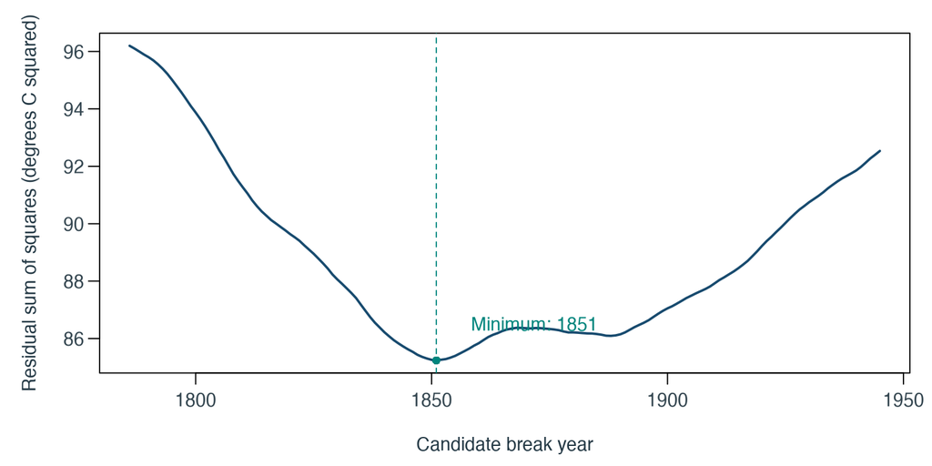

RSS at every admissible break date; the minimum selects the observed break.

```r
plot_pair("break_profile", function() {
    setup()
    plot(year[candidates], rss, type = "l", lwd = 2, col = navy, xlab = "Candidate break year",
        ylab = "Residual sum of squares (degrees C squared)")
    abline(v = year[k], col = teal, lty = 2)
    points(year[k], min(rss), pch = 16, col = teal)
    text(year[k] + 5, min(rss) + 1.2, paste("Minimum:", year[k]), pos = 4, col = teal)
}, 8, 4)

knitr::include_graphics(file.path(artifact_root, "figures/break_profile.png"))
```

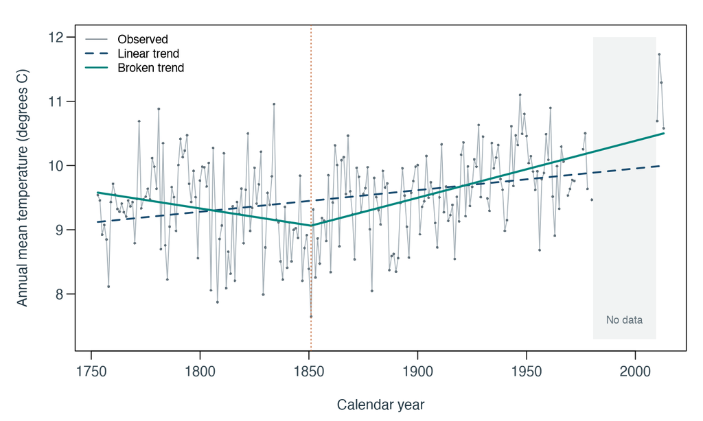

Observed temperatures, linear fit and continuous broken trend. Fitted curves across gaps are model-implied.

```r
plot_pair("temperature_fits", function() {
    setup()
    plot(year, y, type = "n", xlab = "Calendar year", ylab = "Annual mean temperature (degrees C)",
        ylim = c(7.3, 12))
    rect(1980.5, 7.3, 2009.5, 12, col = gap_fill, border = NA)
    series_lines(y, gray_line)
    points(year, y, pch = 16, cex = 0.42, col = gray)
    lines(year, fitted(m0), col = navy, lwd = 2, lty = 2)
    lines(year, fitted(m1), col = teal, lwd = 2.3)
    abline(v = year[k], col = rust, lty = 3)
    text(1995, 7.6, "No data", cex = 0.75, col = gray)
    legend("topleft", c("Observed", "Linear trend", "Broken trend"), col = c(gray, navy,
        teal), lty = c(1, 2, 1), lwd = c(1, 2, 2), bty = "n", cex = 0.85)
})

knitr::include_graphics(file.path(artifact_root, "figures/temperature_fits.png"))
```

## 4.2 Choice of bootstrap procedures

**Why bootstrap inference.** Under $H_0:\delta=0$ the break date is not identified, so $F_T$, which maximises the fit improvement over all candidate dates, does not follow a standard $F$ or $\chi^2$ distribution. No closed-form finite-sample distribution is available, and asymptotic critical values would have to be adapted to the trending design, the unequal spacing and the dependent errors. The bootstrap approximates the null distribution of the entire procedure, including the date search, by resampling.

**Which bootstrap.** Section 3 found evidence of positive serial dependence (Monte Carlo DW p = 0.0002), while BP did not reject homoskedasticity against a linear variance trend (conventional p = 0.5183). This non-rejection does not establish constant variance, and the usual BP p-value does not adjust for serial dependence. The primary procedure must therefore preserve serial dependence. We adopt the dependent wild bootstrap (DWB; Shao, 2010). It preserves short-range dependence through correlated multipliers and keeps each observation’s own residual magnitude. Unlike a block bootstrap, it handles unequally spaced observations directly: the multiplier correlation decays with calendar distance, so no block has to straddle the 1981–2009 gap.

Two secondary procedures provide a sensitivity analysis and together form a controlled comparison. The IID residual bootstrap preserves neither dependence nor observation-specific variance. The independent wild bootstrap (Wu, 1986; Liu, 1988) preserves observation-specific variance but not dependence. It is included as a variance-robust sensitivity check: BP non-rejection against a linear variance trend does not rule out other variance patterns. Comparing the IID residual and wild bootstraps assesses sensitivity to the treatment of observation-specific variance; comparing the wild bootstrap and the DWB assesses sensitivity to the treatment of serial dependence.

**Restricted residuals and the role of the bandwidth.** All procedures resample residuals from the null (linear) model and generate samples around the fitted null mean. This targets $H_0$ but does not guarantee accurate finite-sample size. If the trend changes, these restricted residuals may contain an unmodelled kink as a slow, low-frequency pattern. Retaining more of this structure at longer DWB bandwidths may raise bootstrap critical values and reduce power. This is a possible mechanism, not a guarantee: p-values need not increase monotonically with bandwidth. Using residuals from the broken-trend fit while still generating samples around the null mean would give a different calibration. Its effects on size and power require a separate comparison and are not established here.

**Bandwidth.** The primary bandwidth $\ell=6$ years follows the common $n^{1/3}$ rate ($n^{1/3}=$ 6.09). Under the exponential kernel used below, it implies a multiplier correlation of $\exp(-1/6)\approx 0.85$ between consecutive years, $\exp(-1)\approx 0.37$ at six years and about $0.14$ at twelve years. The residual autocorrelation in Section 3 is positive but moderate at short lags (calendar lag-one autocorrelation 0.30), so a six-year kernel covers the short-range dependence without reaching deeply into the low-frequency trend component. The bandwidths $\ell=3$ and $\ell=12$ are reported as sensitivity checks.

## 4.3 Bootstrap error generators

The IID residual bootstrap samples centered residuals with replacement. It targets independent, identically distributed errors. The independent wild bootstrap multiplies each residual by an independent Rademacher sign, retaining its location-specific squared magnitude but removing serial dependence.

The primary dependent wild bootstrap (DWB) uses correlated Gaussian multipliers:

$$w_1\sim N(0,1),\quad
a_i=\exp[-(s_i-s_{i-1})/\ell],\quad
w_i=a_iw_{i-1}+\sqrt{1-a_i^2}z_i,$$

where $z_i$ are independent standard Gaussians. This gives $\operatorname{Cov}(w_i,w_j)=\exp(-|s_i-s_j|/\ell)$. Using actual calendar gaps weakens multiplier dependence across missing years without imputing temperatures. The multiplier correlation is a chosen dependence approximation, not a fitted error autocorrelation.

Residuals are centered and multiplied by $\sqrt{n/(n-p)}$: $p=2$ for the linear null and $p=3$ for the fitted broken alternative. This offsets residual shrinkage from estimating the linear coefficients. The primary bandwidth is six years, approximately $\operatorname{round}(n^{1/3})$.

```r
dwb_weights <- function(design, B, ell = round(design$n^(1/3))) {
  stopifnot(B >= 1L, ell > 0)
  w <- matrix(rnorm(design$n * B), nrow = design$n, ncol = B)
  a <- exp(-diff(design$year) / ell)
  for (i in 2L:design$n)
    w[i, ] <- a[i - 1L] * w[i - 1L, ] + sqrt(1 - a[i - 1L]^2) * w[i, ]
  w
}
```

```r
bootstrap_errors <- function(e, year, B, method, ell = 6, df = 2) {
  n <- length(e)
  stopifnot(length(year) == n, n > df, all(is.finite(e)),
            all(is.finite(year)), B >= 1L,
            length(method) == 1L, method %in% c("iid", "wild", "dwb"))
  e <- (e - mean(e)) * sqrt(n / (n - df))
  switch(method,
    iid = matrix(sample(e, n * B, replace = TRUE), nrow = n),
    wild = e * matrix(2L * sample.int(2L, n * B, replace = TRUE) - 3L,
                      nrow = n),
    dwb = e * dwb_weights(list(n = n, year = year), B, ell))
}
```

## 4.4 Bootstrap algorithms

### 4.4.1 Algorithm A: bootstrap test of the no-break null

All three procedures share the same null-imposed generation step and differ only in how $e_i^*$ is drawn. Let $\widehat y_{0i}$ and $\widehat e_{0i}$ denote the fitted values and residuals of the linear (no-break) null model `m0`, estimated by OLS on the full observed sample.

1. **Model estimated under the null.** $y_i=\beta_0+\beta_1 t_i+\varepsilon_i$ is refit by OLS on the observed data; $\widehat y_{0i}$ and $\widehat e_{0i}$ are held fixed across every bootstrap replication and every procedure.
2. **Residuals/innovations resampled.** All three procedures resample the null-model residuals $\widehat e_{0i}$ themselves; DWB reweights them with a dependent multiplier rather than drawing a fresh independent sample.
3. **Centering/rescaling.** In `bootstrap_errors()`, residuals are first centered, $\widehat e_{0i}-\bar{\widehat e}_0$, then inflated by $\sqrt{n/(n-p)}$ with $p=2$ (two null parameters) to offset the standard OLS shrinkage of residual variance, before any resampling is applied.
4. **Generating** $y_1^*,\dots,y_n^*$.
   - *IID residual*: $e^*=\text{sample}(\widehat e_0,\ \text{replace}=TRUE)$.
   - *Independent wild*: $e_i^*=\widehat e_{0i}\cdot\xi_i$, $\xi_i\overset{iid}{\sim}\{-1,+1\}$ equiprobable (Rademacher).
   - *Dependent wild (DWB)*: $e_i^*=\widehat e_{0i}\cdot w_i$, with $w_i$ a mean-zero, unit-variance Gaussian sequence, $\operatorname{Cov}(w_i,w_j) =\exp(-|s_i-s_j|/\ell)$ built from actual calendar years $s_i$ (`dwb_weights()`), $\ell=6$ for the primary specification.
   - In every case $y_i^*=\widehat y_{0i}+e_i^*$; because the null mean lies in the space spanned by the projected-out regressors, the break statistic computed from $e^*$ alone equals the one computed from $y^*$, so the code operates directly on $e^*$ for speed.
5. **Computing** $F_T^*$, the critical value and the $p$-value. For every bootstrap draw, `break_statistics()` reruns the *entire* break search over all admissible dates and returns $F_T^*=RSS_0^*-\min_{T_c\in\Lambda}RSS_1^*(T_c)$ — the date is reselected in each replication, never held fixed at $\widehat T_1$. The empirical 95% critical value is the type-1 sample quantile of $F_{T}^{*(1)},\dots, F_{T}^{*(B)}$, and the $p$-value uses the finite-$B$ correction $p=\bigl(1+\#\{b:F_{T,b}^*\ge F_T\}\bigr)/(B+1)$.
6. **Preserving dependence/heteroskedasticity.** IID residual bootstrap preserves neither. Independent wild preserves each observation’s own residual magnitude (hence any heteroskedasticity in $\widehat e_{0i}^2$) but destroys serial dependence, since $\xi_i$ is independent across $i$. DWB preserves both: $w_i$ has variance 1, so $e_i^{*2}$ keeps the same conditional scale as $\widehat e_{0i}^2$, while $\operatorname{Cov}(w_i, w_j)\neq 0$ for nearby calendar years reproduces the short-range positive serial dependence flagged by the Section 3 Durbin–Watson test.

| Element | IID residual | Independent wild | Dependent wild (primary) |
| --- | --- | --- | --- |
| Null model | linear trend `m0` | same | same |
| Resampled quantity | centered/rescaled $\widehat e_0$ | same, sign-flipped | same, Gaussian-multiplier-weighted |
| Centering/rescaling | mean 0, $\times\sqrt{n/(n-2)}$ | same | same |
| $y^*$ generator | $\widehat y_0+\text{sample}(\widehat e_0)$ | $\widehat y_0+\widehat e_0\,\xi$ | $\widehat y_0+\widehat e_0\,w$ |
| $F_T^*$, critical value, $p$-value | reselect break; type-1 quantile; $(1+\#\{\cdot\})/(B{+}1)$ | same | same |
| Preserves dependence? | No | No | Yes ($\ell=6$ calendar years) |
| Preserves heteroskedasticity? | No | Yes | Yes |

### 4.4.2 Algorithm B: bootstrap confidence intervals for the slopes

The intervals use the primary DWB only and generate data under the fitted broken-trend alternative (Davison and Hinkley, 1997, ch. 5):

1. **Model estimated.** Fit the broken-trend model at $\widehat T_1$, giving fitted values $\widehat y_{1i}$, residuals $\widehat e_{1i}$ and slope estimates $\widehat\theta=(\widehat\beta,\ \widehat\beta+\widehat\delta)$. Compute calendar-time HAC standard errors $s=(s_{\mathrm{pre}},s_{\mathrm{post}})$ as described below.
2. **Centring and rescaling.** Centre $\widehat e_{1i}$ and multiply by $\sqrt{n/(n-3)}$, reflecting the three regression coefficients.
3. **Bootstrap samples.** For $b=1,\ldots,B$ with $B=$ 4999, draw DWB multipliers $w^{(b)}$ with $\ell=6$ and set $y^{*(b)}_i=\widehat y_{1i}+\widehat e_{1i}\,w_i^{(b)}$.
4. **Re-estimation.** For each $y^{*(b)}$, repeat the entire break search over $\Lambda$, re-estimate the model at the reselected date $\widehat T_1^{*(b)}$, and record $\widehat\theta^{*(b)}$ and its HAC standard errors $s^{*(b)}$, computed exactly as $s$.
5. **Intervals.** The percentile interval is $[q_{0.025}(\widehat\theta^*),\ q_{0.975}(\widehat\theta^*)]$. The percentile-$t$ interval uses $t^{*(b)}=(\widehat\theta^{*(b)}-\widehat\theta)/s^{*(b)}$ and is $[\widehat\theta-q_{0.975}(t^*)\,s,\ \widehat\theta-q_{0.025}(t^*)\,s]$.
6. **Dependence and heteroskedasticity.** As in Algorithm A, the DWB multipliers preserve short-range dependence and observation-specific variance. Re-selecting the date in step 4 carries break-date uncertainty into the slope intervals.

## 4.5 Bootstrap test of the no-break null

For a break test, bootstrap samples must impose the no-break null. Fit the linear model, generate $e_i^*$ from its residuals, and form $y_i^*=\widehat y_{0i}+e_i^*$. Refit the null and search every admissible break in each draw. Because the linear mean lies in the projected-out space, evaluating the statistic on $e^*$ alone is algebraically identical and faster.

The 95% critical value uses the type-1 empirical quantile. The corrected upper-tail probability is

$$p=\frac{1+\sum_{b=1}^B\mathbf
1\{F_{T,b}^*\ge F_T\}}{B+1}.$$

The null is rejected at the 5% level when $p\le 0.05$. The function below implements Algorithm A and is also used in the simulation study of Section 5; for the empirical application, the subsequent chunk stores all bootstrap statistics for plotting.

```r
bootstrap_break <- function(y, design, B = 999L,
                            methods = c("iid", "wild", "dwb"),
                            seed = NULL, ell = round(design$n^(1/3)),
                            level = 0.05, keep_statistics = FALSE) {
  B <- as.integer(B)
  stopifnot(B >= 1L, level > 0, level < 1,
            length(methods) > 0, all(methods %in% c("iid", "wild", "dwb")),
            !anyDuplicated(methods))
  if (!is.null(seed)) set.seed(seed)
  observed <- fit_break(y, design)
  # Null-restricted residuals enforce the hypothesis in every bootstrap draw.
  # Degrees-of-freedom correction offsets shrinkage from estimating two terms.
  e <- observed$null_residuals
  results <- vector("list", length(methods)); names(results) <- methods
  for (method in methods) {
    boot_errors <- bootstrap_errors(e, design$year, B, method, ell, df = 2)
    # Adding the fitted null trend leaves this residual-projection statistic
    # unchanged, so computing directly from bootstrap errors is exact.
    Fstar <- break_statistics(boot_errors, design)$F
    p <- (1 + sum(Fstar >= observed$F)) / (B + 1)
    result <- list(method = method, F = observed$F, p_value = p,
                   critical = unname(quantile(Fstar, 1 - level, type = 1)),
                   reject = p <= level, B = B, level = level,
                   ell = if (method == "dwb") ell else NA_real_)
    if (keep_statistics) result$statistics <- Fstar
    results[[method]] <- result
  }
  list(observed = observed, results = results)
}
```

```r
methods <- c("iid", "wild", "dwb")

btests <- list()

draws <- list()

for (j in seq_along(methods)) {
    set.seed(seed + 100L + j)
    err <- bootstrap_errors(e0, year, B_test, method = methods[j], ell = 6, df = 2)
    fs <- break_statistics(err, design)$F
    draws[[methods[j]]] <- fs
    btests[[j]] <- data.frame(method = methods[j], ell = ifelse(methods[j] == "dwb", 6, NA),
        B = B_test, statistic = Fobs, critical95 = quantile(fs, 0.95, type = 1, names = FALSE),
        p_value = (1 + sum(fs >= Fobs))/(B_test + 1), exceedances = sum(fs >= Fobs))
}

for (ell in c(3L, 12L)) {
    set.seed(seed + 200L + ell)
    err <- bootstrap_errors(e0, year, B_test, method = "dwb", ell = ell, df = 2)
    fs <- break_statistics(err, design)$F
    btests[[length(btests) + 1]] <- data.frame(method = "dwb", ell = ell, B = B_test, statistic = Fobs,
        critical95 = quantile(fs, 0.95, type = 1, names = FALSE), p_value = (1 + sum(fs >=
            Fobs))/(B_test + 1), exceedances = sum(fs >= Fobs))
}

btests <- do.call(rbind, btests)

write_csv(btests, "tables/bootstrap_tests.csv")
```

```r
bandwidth <- btests[btests$method=="dwb",]
for(ell in setdiff(2:15,bandwidth$ell))
{
  set.seed(seed+200L)
  err<-bootstrap_errors(e0,year, B_test, "dwb", ell, df = 2)
  fs <- break_statistics(err,design)$F
  bandwidth <- rbind(bandwidth, data.frame(method = "dwb", ell = ell, B = B_test, statistic = Fobs, critical95=quantile(fs, .95, type = 1, names = FALSE), p_value = (1+sum(fs>=Fobs)) / (B_test + 1), exceedances = sum(fs >= Fobs)))
}

bandwidth <- bandwidth[order(bandwidth$ell),]

#Wilson intervals
z<- qnorm(.975); tail_rate <- bandwidth$exceedances /B_test
centre <- (tail_rate + z^2 / (2 * B_test)) / (1 + z^2 / B_test)
half <- z * sqrt(tail_rate * (1 - tail_rate) / B_test +
                 z^2 / (4 * B_test^2)) / (1 + z^2 / B_test)
bandwidth$lower_95 <- pmax(0, centre - half)
bandwidth$upper_95 <- pmin(1, centre + half)
write_csv(bandwidth, "tables/bandwidth_sensitivity.csv")
```

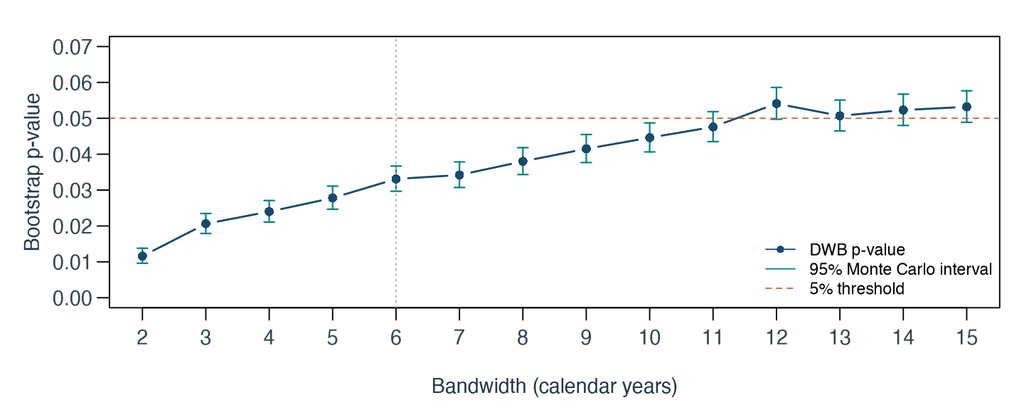

Dependent wild bootstrap p-values over bandwidths 2–15 calendar years, with 9,999 draws at each bandwidth. Vertical bars are 95% Wilson intervals for conditional Monte Carlo tail probabilities; the dashed line marks the 5% threshold and the dotted line marks the primary bandwidth of six years.

```r
plot_pair("bandwidth_sensitivity", function() {
  setup()
  plot(bandwidth$ell, bandwidth$p_value, type = "b", pch = 16,
       col = navy, lwd = 1.5, xaxt = "n", ylim = c(0, 0.07),
       xlab = "Bandwidth (calendar years)", ylab = "Bootstrap p-value")
  axis(1, at = 2:15)
  arrows(bandwidth$ell, bandwidth$lower_95,
         bandwidth$ell, bandwidth$upper_95,
         angle = 90, code = 3, length = 0.04, col = teal, lwd = 1.2)
  abline(h = 0.05, lty = 2, col = rust)
  abline(v = 6, lty = 3, col = gray_line)
  points(bandwidth$ell, bandwidth$p_value, pch = 16, col = navy)
  legend("bottomright", c("DWB p-value", "95% Monte Carlo interval", "5% threshold"),
         col = c(navy, teal, rust), pch = c(16, NA, NA),
         lty = c(1, 1, 2), bty = "n", cex = 0.8)
}, width = 8, height = 3.2)
knitr::include_graphics(file.path(artifact_root, "figures/bandwidth_sensitivity.png"))
```

The full bandwidth grid gives p-values from 0.0116 to 0.0541. Bandwidths 2–11 reject at 5%, whereas 12–15 do not in this run; the curve need not be monotone. The primary bandwidth remains six years, rather than being selected to obtain the smallest p-value. This sensitivity qualifies the strength of the break evidence. The Wilson intervals describe Monte Carlo uncertainty in each fixed-bandwidth tail probability; they do not measure uncertainty about which bandwidth is appropriate.

```r
bootstrap_table <- btests
bootstrap_table$Procedure <- c("IID residual", "Independent wild", "Dependent wild: ell=6",
                               "Dependent wild: ell=3", "Dependent wild: ell=12")
bootstrap_table$Decision <- ifelse(bootstrap_table$p_value <= .05, "Reject", "Do not reject")
knitr::kable(bootstrap_table[, c("Procedure", "B", "statistic", "critical95", "p_value", "Decision")],
             digits = 4, caption = "Unknown-break tests and dependent-wild bandwidth sensitivity")
```

Unknown-break tests and dependent-wild bandwidth sensitivity

| Procedure | B | statistic | critical95 | p_value | Decision |
| --- | --- | --- | --- | --- | --- |
| IID residual | 9999 | 12.2106 | 2.6433 | 0.0001 | Reject |
| Independent wild | 9999 | 12.2106 | 3.4256 | 0.0001 | Reject |
| Dependent wild: ell=6 | 9999 | 12.2106 | 10.5919 | 0.0331 | Reject |
| Dependent wild: ell=3 | 9999 | 12.2106 | 8.7722 | 0.0206 | Reject |
| Dependent wild: ell=12 | 9999 | 12.2106 | 12.6082 | 0.0541 | Do not reject |

Each procedure uses 9999 bootstrap replications. The primary DWB with $\ell=6$ gives $p=$ 0.0331, which rejects the no-break null at the 5% level. With $\ell=3$ the p-value is 0.0206, and with $\ell=12$ it is 0.0541. The p-values increase with bandwidth in these runs. The possible restricted-residual mechanism discussed above is one explanation, but this pattern is not a general monotonicity property of the DWB. The ell = 12 result lies just above the 5% threshold. The conclusion at the conventional level is therefore bandwidth-sensitive, and the evidence for a break is better described as moderate than as decisive.

If the no-break null is not rejected under a given specification, $\widehat T_1=$ 1851 cannot be read as an identified break point under that specification. The search always returns *some* date, because it is defined as an arg-min over $\Lambda$, but a date obtained alongside an unrejected test is a descriptive optimum of this sample, not evidence that the population trend changed there. The fitted broken trend is then one flexible descriptive fit nested against the linear trend, not a confirmed two-regime model.

The IID residual and independent wild bootstraps give p-values of 0.0001 and 0.0001. Neither produced a single bootstrap statistic as large as the observed one, so both p-values equal the smallest attainable value 1/(B+1). This reflects finite simulation resolution, not a zero tail probability or a confidence bound on the underlying tail probability. Both procedures reject at the 5% level, but their common rejection decision does not establish that observation-specific variance is unimportant. Their identical minimum p-values cannot resolve differences below the simulation resolution. The contrast between these two procedures and the DWB shows that the evidence depends on how serial dependence is treated. Because the independent procedures ignore the dependence detected in Section 3, their smaller p-values do not override the primary calibration; Section 5 shows that such procedures over-reject when errors are autocorrelated.

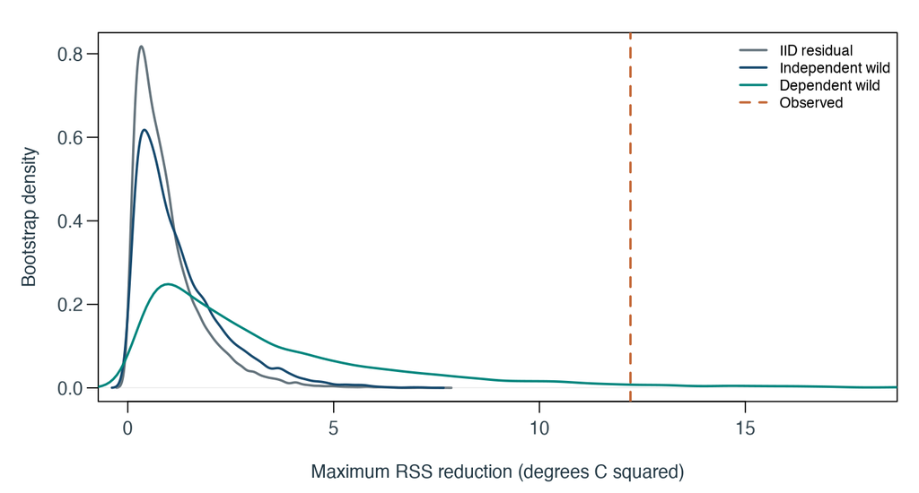

Null bootstrap distributions under the three primary procedures; the dashed line marks the observed RSS reduction.

```r
plot_pair("bootstrap_null", function() {
    setup()
    dd <- lapply(draws, density)
    xmax <- max(Fobs, sapply(draws, quantile, 0.99))
    plot(dd[[1]], xlim = c(0, xmax * 1.05), col = gray, lwd = 2, xlab = "Maximum RSS reduction (degrees C squared)",
        ylab = "Bootstrap density", main = "")
    lines(dd[[2]], col = navy, lwd = 2)
    lines(dd[[3]], col = teal, lwd = 2)
    abline(v = Fobs, col = rust, lwd = 2, lty = 2)
    legend("topright", c("IID residual", "Independent wild", "Dependent wild", "Observed"), col = c(gray,
        navy, teal, rust), lty = c(1, 1, 1, 2), lwd = 2, bty = "n", cex = 0.8)
}, 8, 4.3)

knitr::include_graphics(file.path(artifact_root, "figures/bootstrap_null.png"))
```

## 4.6 Estimated broken trend in light of the test

At $\widehat T_1=$ 1851, the estimated pre-break trend is $\widehat\beta=$ -0.0525 °C per decade, the estimated change in trend is $\widehat\delta=$ 0.1412 °C per decade, and the estimated post-break trend is $\widehat\beta+\widehat\delta=$ 0.0887 °C per decade (0.89 °C per century). Over the 162 years from the estimated break to the end of the record, the post-break slope implies a fitted warming of about 1.44 °C, compared with 0.55 °C implied by the single linear trend over the same period.

Two statements must be kept apart. The first is descriptive: among all continuous one-break trends, the one with a kink at 1851 fits best, and it describes the record as slight cooling followed by clearer warming. The second is inferential: whether the data provide evidence that the trend changed at all. That question is answered by the bootstrap test above, which supports a break under the primary procedure, subject to the bandwidth sensitivity noted there. The estimated slopes and date are meaningful as a description regardless of the test outcome, but they can be read as an estimate of a structural change only to the extent that the test supports one. The uncertainty of the slopes is quantified next.

## 4.7 Bootstrap confidence intervals for the slopes

### 4.7.1 Studentisation: calendar-time HAC standard errors

The percentile-$t$ interval requires a standard error in every bootstrap sample, so that the studentised statistic $t^*$ is approximately pivotal, which typically makes the interval more accurate than the percentile interval. Because the errors are serially dependent, conventional OLS standard errors would misstate the sampling variability, so we use a heteroskedasticity and autocorrelation consistent (HAC) estimator in the spirit of Newey and West (1987), adapted to calendar time.

Confidence intervals generate data under the **fitted broken alternative**, rather than the null. Each draw repeats the date search and re-estimates both slopes. Percentile intervals use the bootstrap slope quantiles. Studentized percentile-$t$ intervals also recompute a standard error in every draw.

The local Jacobian contains the date derivative:

$$J_i=[1,x_i,(x_i-\tau)_+,-\widehat\delta\mathbf
1(x_i>\tau)],\qquad \tau=x_{\widehat k}.$$

For numerical stability, the fourth column is rescaled to the indicator $\mathbf 1(x_i>\tau)$. With a nonzero slope change, this does not change the covariance of the first three coefficients. The pre- and post-break contrasts are $(0,1,0,0)$ and $(0,1,1,0)$.

The calendar Bartlett kernel is $K_{ij}=\max\{1-|s_i-s_j|/7,0\}$. Only observed pairs exactly one to six calendar years apart enter the lag terms. The finite-sample multiplier is $n/(n-4)$, counting the local date parameter as well as the three regression coefficients. This is a local HAC approximation, and weak date identification can limit coverage.

```r
calendar_hac_se <- function(year, X, e, L=6) {
  n <- nrow(X); p <- ncol(X); A <- solve(crossprod(X))
  C <- cbind(c(0,1,0,0),c(0,1,1,0))
  influence <- (X %*% A %*% C)*as.numeric(e)
  v <- colSums(influence^2)
  for (lag in seq_len(L)) {
    j <- match(year+lag,year); i <- which(!is.na(j))
    if(length(i)) v <- v+2*(1-lag/(L+1))*colSums(influence[i,,drop=FALSE]*influence[j[i],,drop=FALSE])
  }
  sqrt(pmax(v*n/(n-p),.Machine$double.eps))
}
```

### 4.7.2 Bootstrap samples under the alternative

The alternative residual scaling uses three linear coefficients, while the local sandwich uses four parameters including the date; these corrections serve different roles. The bootstrap loop records reselected dates, slope estimates and their HAC standard errors, making the reported intervals independently reconstructible.

```r
# Alternative bootstrap: both break location and slope estimates are refitted.
set.seed(seed+301L)
err<-bootstrap_errors(e1,year,B_ci,method="dwb",ell=6,df=3)
Ystar<-as.numeric(fitted(m1))+err
coefstar<-sestar<-matrix(NA_real_,B_ci,2); breakyears<-integer(B_ci)
seobs<-calendar_hac_se(year,cbind(X1,as.numeric(x>x[k])),e1)
for (b in seq_len(B_ci)) {
  ff<-fit_break(Ystar[,b],design); kk<-ff$index
  XX<-cbind(1,x,pmax(0,x-x[kk])); fit<-lm.fit(XX,Ystar[,b])
  coefstar[b,]<-c(fit$coefficients[2],sum(fit$coefficients[2:3]))
  sestar[b,]<-calendar_hac_se(year,cbind(XX,as.numeric(x>x[kk])),fit$residuals)
  breakyears[b]<-year[kk]
}
```

For either slope $\theta$, the percentile interval is $[q_{.025}(\widehat\theta^*),q_{.975}(\widehat\theta^*)]$. For the studentized interval, calculate

$$t^*=\frac{\widehat\theta^*-\widehat\theta}{s^*},\qquad
[\widehat\theta-q_{.975}(t^*)s,\
\widehat\theta-q_{.025}(t^*)s].$$

CI quantiles use R’s interpolated type 7. Notice the reversed quantile order in the studentized endpoints. Holding the selected date fixed in bootstrap samples would omit part of slope uncertainty.

```r
tstar<-sweep(sweep(coefstar,2,theta,"-"),c(1,2),sestar,"/")
cis<-do.call(rbind,lapply(1:2,function(j){
  pc<-quantile(coefstar[,j],c(.025,.975),type=7,names=FALSE)
  qt<-quantile(tstar[,j],c(.975,.025),type=7,names=FALSE)
  pt<-theta[j]-seobs[j]*qt
  data.frame(parameter=c("pre","post")[j],estimate=unname(theta[j]),hac_se=unname(seobs[j]),
             type=c("percentile","percentile_t"),lower=c(pc[1],pt[1]),upper=c(pc[2],pt[2]),B=B_ci)
}))
write_csv(cis,"tables/confidence_intervals.csv")
knitr::kable(cis, digits = 4, caption = "Nominal 95% intervals in degrees C per decade")
```

Nominal 95% intervals in degrees C per decade

| parameter | estimate | hac_se | type | lower | upper | B |
| --- | --- | --- | --- | --- | --- | --- |
| pre | -0.0525 | 0.0300 | percentile | -0.2601 | 0.0051 | 4999 |
| pre | -0.0525 | 0.0300 | percentile_t | -0.1804 | 0.0343 | 4999 |
| post | 0.0887 | 0.0192 | percentile | 0.0511 | 0.1551 | 4999 |
| post | 0.0887 | 0.0192 | percentile_t | 0.0318 | 0.1601 | 4999 |

Both pre-break intervals contain zero. Statistically, the data are compatible with no trend before the break; substantively, the negative point estimate does not establish early cooling. Both post-break intervals lie entirely above zero. Statistically, a zero post-break slope is not supported within the broken-trend model; substantively, this indicates sustained warming at this station after the estimated break. These intervals are conditional on the broken-trend specification and do not by themselves test whether a break exists. Their coverage has not been evaluated by simulation (Section 5 studies test size and power only), and the percentile-$t$ intervals rely on a local HAC approximation, which may be less accurate where the date is weakly identified.

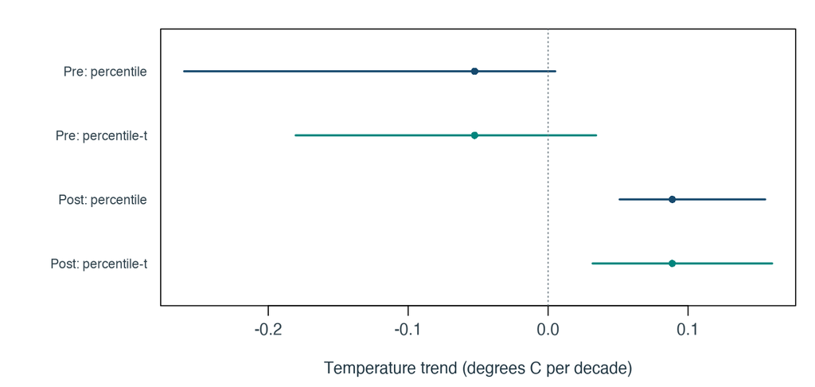

Percentile and percentile-t intervals; the vertical reference marks zero slope.

```r
plot_pair("slope_intervals", function() {
    setup()
    par(mar = c(4.2, 8.3, 1.5, 1))
    yy <- 4:1
    cols <- rep(c(navy, teal), 2)
    plot(cis$estimate, yy, xlim = range(c(cis$lower, cis$upper, 0)), ylim = c(0.5, 4.5),
        yaxt = "n", xlab = "Temperature trend (degrees C per decade)", ylab = "", pch = 16,
        col = cols)
    segments(cis$lower, yy, cis$upper, yy, col = cols, lwd = 2)
    abline(v = 0, lty = 3, col = gray)
    axis(2, at = yy, labels = c("Pre: percentile", "Pre: percentile-t", "Post: percentile",
        "Post: percentile-t"), las = 1, tick = FALSE, cex.axis = 0.8)
}, 8, 3.8)

knitr::include_graphics(file.path(artifact_root, "figures/slope_intervals.png"))
```

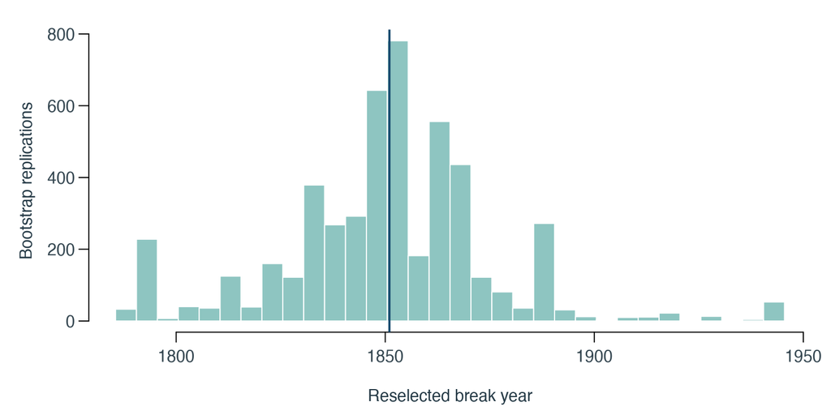

Reselected dates across all alternative-bootstrap samples.

```r
plot_pair("break_bootstrap_distribution", function() {
    setup()
    hist(breakyears, breaks = seq(min(year[candidates]) - 0.5, max(year[candidates]) + 4.5,
        by = 5), col = teal_fill, border = "white", xlab = "Reselected break year", ylab = "Bootstrap replications",
        main = "")
    abline(v = year[k], col = navy, lwd = 2)
}, 8, 4)

knitr::include_graphics(file.path(artifact_root, "figures/break_bootstrap_distribution.png"))
```

```r
knitr::kable(data.frame(
  Lower_date_percentile = unname(quantile(breakyears, .025)),
  Upper_date_percentile = unname(quantile(breakyears, .975)),
  Boundary_selection_percent = 100 * mean(breakyears %in% range(year[candidates]))
), digits = 2)
```

| Lower_date_percentile | Upper_date_percentile | Boundary_selection_percent |
| --- | --- | --- |
| 1793 | 1896 | 1.54 |

The date percentiles describe selection variability under the fitted alternative. They are not an established 95% confidence set for a weakly identified break date. The spread of reselected dates contributes to the width and possible asymmetry of the slope intervals.

## 4.8 Model comparison and residual diagnostics

RSS, in-sample RMSE and $R^2$ describe fit. A searched model is more flexible, so improvement alone is not selection-adjusted evidence. The bootstrap addresses that distinction. The broken residuals should also be inspected rather than assuming that a new mean model removes dependence.

```r
diagnostic<-function(m,label){
  e<-resid(m); bb<-n*summary(lm(e^2~x))$r.squared
  data.frame(model=label,RSS=sum(e^2),RMSE=sqrt(mean(e^2)),R2=summary(m)$r.squared,
    adjusted_R2=summary(m)$adj.r.squared,DW=sum(diff(e)^2)/sum(e^2),
    acf1=acf(e,plot=FALSE)$acf[2],BP=bb,BP_p=pchisq(bb,1,lower.tail=FALSE))
}
dg<-rbind(diagnostic(m0,"linear"),diagnostic(m1,"broken"))
write_csv(dg,"tables/model_diagnostics.csv")
knitr::kable(dg, digits = 4, caption = "Fit measures and remaining residual dependence")
```

Fit measures and remaining residual dependence

| model | RSS | RMSE | R2 | adjusted_R2 | DW | acf1 | BP | BP_p |
| --- | --- | --- | --- | --- | --- | --- | --- | --- |
| linear | 97.4474 | 0.6566 | 0.1054 | 0.1014 | 1.4147 | 0.2900 | 0.4173 | 0.5183 |
| broken | 85.2367 | 0.6141 | 0.2175 | 0.2104 | 1.6129 | 0.1935 | 1.5753 | 0.2094 |

The reduction in RSS is 12.53%. RMSE falls from 0.657 to 0.614 °C, and $R^2$ rises from 0.105 to 0.217. Most annual variation remains unexplained by either model.

Because the broken model estimates a break date in addition to its three coefficients, adjusted $R^2$, which counts only three parameters, slightly overstates its advantage. A Bayesian information criterion that counts the date as a fourth parameter, $\mathrm{BIC}=n\log(RSS/n)+p\log n$, equals -179.3 for the linear model ($p=2$) and -198.7 for the broken model ($p=4$), so the broken trend is preferred even after this penalty. Because the break date enters the model non-regularly, BIC is only a heuristic here; the bootstrap test remains the formal comparison.

The Durbin–Watson statistic of the broken-trend residuals (1.613) is closer to two than that of the linear model (1.415), and the observation-lag ACF(1) falls from 0.290 to 0.194. These values are not formally calibrated: the design now depends on the estimated date, so the Section 3 critical values do not apply. Together with the residual ACF below, they indicate that the kink absorbs part, but not all, of the residual dependence, which supports using a dependence-robust bootstrap for the slope intervals.

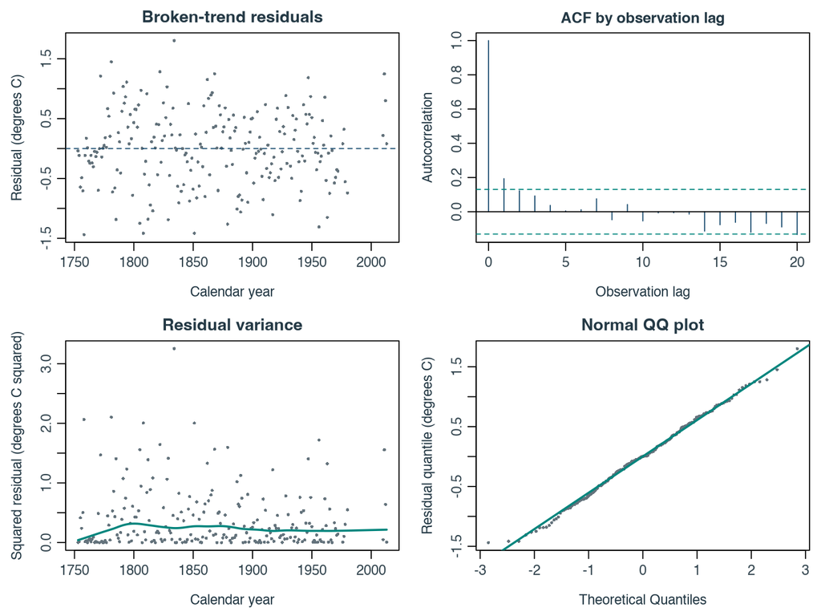

Residual diagnostics after selecting the broken trend; dependence remains visible.

```r
plot_pair("diagnostics_broken", function() {
    par(mfrow = c(2, 2), mar = c(4, 4, 2, 0.7), mgp = c(2.5, 0.7, 0),
        col.axis = axis_colour, col.lab = label_colour,
        col.main = label_colour, cex = 0.8)
    plot(year, e1, pch = 16, cex = 0.5, col = gray, xlab = "Calendar year", ylab = "Residual (degrees C)",
        main = "Broken-trend residuals")
    abline(h = 0, col = navy, lty = 2)
    acf(e1, lag.max = 20, main = "", xlab = "Observation lag", ylab = "Autocorrelation",
        col = navy, ci.col = teal)
    title("ACF by observation lag", line = 0.6, cex.main = 1.1)
    plot(year, e1^2, pch = 16, cex = 0.5, col = gray, xlab = "Calendar year", ylab = "Squared residual (degrees C squared)",
        main = "Residual variance")
    lines(lowess(year, e1^2, f = 0.3), col = teal, lwd = 2)
    qqnorm(e1, pch = 16, cex = 0.5, col = gray, main = "Normal QQ plot", ylab = "Residual quantile (degrees C)")
    qqline(e1, col = teal, lwd = 2)
}, 8, 6)

knitr::include_graphics(file.path(artifact_root, "figures/diagnostics_broken.png"))
```

**Overall comparison.** Substantively, the broken trend is the more convincing description: it replaces a single average slope with a flat-to-cooling phase followed by warming, matches the pattern seen in Section 2, and yields a post-break slope 2.6 times the linear slope. Statistically, the case is supported but not decisive: the fit improvement survives a penalty for the additional parameters and the primary bootstrap test rejects the linear model, but the conclusion is sensitive to the dependence bandwidth, and residual dependence remains in both models.

## 4.9 Sensitivity to individual observations

Two descriptive checks omit the coldest observation in 1851 or end the sample in 1980, excluding the four observations after the long gap. Each check reselects the break using 15% trimming. These are point-estimate sensitivities, not new bootstrap significance tests. Every primary result above retains the complete supplied sample.

```r
# Secondary diagnostics only: retain the complete sample for every primary result.
sensitivities <- list(no_coldest = which(year != 1851), pre_gap = which(year <= 1980))

ss <- lapply(names(sensitivities), function(label) {
    ii <- sensitivities[[label]]
    fit <- fit_break(y[ii], prepare_design(year[ii]))
    xx <- (year[ii] - mean(year[ii]))/10
    mm <- lm(y[ii] ~ xx + I(pmax(0, xx - xx[fit$index])))
    data.frame(sample = label, n = length(ii), break_year = year[ii][fit$index], pre = coef(mm)[2],
        post = sum(coef(mm)[2:3]), F = fit$F)
})

write_csv(do.call(rbind, ss), "tables/sample_sensitivity.csv")

sample_sensitivity <- read.csv("tables/sample_sensitivity.csv")

knitr::kable(sample_sensitivity, digits = 4)
```

| sample | n | break_year | pre | post | F |
| --- | --- | --- | --- | --- | --- |
| no_coldest | 225 | 1853 | -0.0464 | 0.0872 | 10.9815 |
| pre_gap | 222 | 1850 | -0.0477 | 0.0776 | 8.6993 |

Excluding 1851 moves the selected date to 1853 and changes $F_T$ from 12.21 to 10.98. Ending the sample in 1980 selects 1850, with a post-break slope of 0.0776 °C per decade. The estimated location of the kink is therefore not an artefact of the coldest year alone or of the four post-gap observations, although the coldest year does contribute to the strength of the fit. These checks do not address unknown station history, model selection or the missing decades.

## 4.10 Stored empirical outputs

All empirical tables, the fitted series, the break-search profile and the bootstrap draws underlying the confidence intervals are written to the working folder, so that every reported number can be reconstructed without rerunning the bootstrap (see Appendix A).

```r
missing <- setdiff(seq(min(year), max(year)), year)

summary <- c(n = n, start = min(year), end = max(year), missing_years = length(missing),
    mean_year = mean(year), centering_year = 1850, mean = mean(y), sd = sd(y), min = min(y), min_year = year[which.min(y)],
    max = max(y), max_year = year[which.max(y)], intercept = coef(m0)[1], linear_slope = coef(m0)[2],
    DW = dw, DW_lower = dwcrit[1], DW_upper = dwcrit[2], DW_p = dwp, BP = bp, BP_p = bpp,
    break_year = year[k], break_index = k, search_first = year[min(candidates)], search_last = year[max(candidates)],
    broken_intercept = coef(m1)[1], pre = theta[1], delta = coef(m1)[3], post = theta[2],
    F = Fobs, sigma = sqrt(sum(e1^2)/(n - 3)), rss_reduction_percent = 100 * Fobs/sum(e0^2),
    ci_break_min = min(breakyears), ci_break_max = max(breakyears), ci_break_lower = quantile(breakyears,
        0.025, names = FALSE), ci_break_upper = quantile(breakyears, 0.975, names = FALSE),
    ci_boundary_percent = 100 * mean(breakyears %in% range(year[candidates])))

names(summary) <- sub("\\..*$", "", names(summary))

write_csv(data.frame(metric = names(summary), value = as.numeric(summary)), "tables/empirical_summary.csv")

write_csv(data.frame(Year = year, Temperature = y, Linear = fitted(m0), Broken = fitted(m1),
    LinearResidual = e0, BrokenResidual = e1), "tables/series_fits.csv")

write_csv(data.frame(year = year[candidates], RSS = rss, reduction = sum(e0^2) - rss), "tables/break_profile.csv")

write_csv(data.frame(Year = missing), "tables/missing_years.csv")

write_csv(data.frame(year = breakyears, pre = coefstar[, 1], post = coefstar[, 2], se_pre = sestar[,
    1], se_post = sestar[, 2]), "tables/ci_draws.csv")

saveRDS(list(summary = summary, tests = btests, ci = cis, diagnostics = dg, draws = draws,
    breakyears = breakyears, design = design, seed = seed, missing = missing), "work/empirical_results.rds")
```

# 5 Simulation study of bootstrap procedures

## 5.1 Data-generating process and experimental factors

The simulation uses 226 equally spaced annual observations and a central true break at index 113:

$$y_t=9.5-0.05x_t+\delta(x_t-x_{113})_++\varepsilon_t,\quad
x_t=(t-\bar t)/10,$$

$$\varepsilon_t=\rho\varepsilon_{t-1}+\sigma_tu_t,\qquad
u_t\sim N(0,1).$$

Eight scenarios cross $\delta\in\{0,0.14\}$, $\rho\in\{0,0.4\}$ and constant or increasing innovation scale. When $\delta=0$, rejection frequency estimates **size** under the no-break null; when $\delta=0.14$, it estimates **power**. The slope change approximates the empirical estimate.

The common innovation scale is calibrated from the empirical broken-model residual standard deviation, $\widehat\sigma=\sqrt{RSS_1/(n-3)}$. For the increasing profile, scales ranging from 0.5 to 1.5 are normalized to have mean square one. This matches average innovation variance across scale conditions; it does not fix marginal error variance across values of $\rho$.

Initialization is stationary for constant scale and a local initialization for changing scale. Unlike the empirical design, the simulated calendar has no missing years; it isolates the selected dependence and variance factors.

```r
simulate_broken_trend <- function(design, delta, rho, heteroskedastic,
                                  sigma, alpha = 9.5, beta = -0.05,
                                  break_index = floor(design$n / 2)) {
  n <- design$n
  scale_profile <- if (heteroskedastic) seq(0.5, 1.5, length.out = n) else rep(1, n)
  # Match average innovation variance across variance-profile conditions.
  scale_profile <- scale_profile / sqrt(mean(scale_profile^2))
  sigma_t <- sigma * scale_profile
  u <- rnorm(n)
  error <- numeric(n)
  # Stationary initialization under the initial innovation scale. For changing
  # sigma_t this is a local initialization, not global stationarity.
  error[1L] <- sigma_t[1L] * u[1L] / sqrt(1 - rho^2)
  for (i in 2L:n) error[i] <- rho * error[i - 1L] + sigma_t[i] * u[i]
  alpha + beta * design$x +
    delta * pmax(0, design$x - design$x[break_index]) + error
}
```

## 5.2 Monte Carlo uncertainty

If $r$ of $M$ datasets reject, the rejection frequency is $\widehat p=r/M$ and its Monte Carlo standard error is $\sqrt{\widehat p(1-\widehat p)/M}$. We also report Wilson intervals. Unlike a plug-in standard error, these remain informative at a rejection rate of 100%. They measure uncertainty in simulation frequencies, not empirical slope uncertainty.

```r
wilson_interval <- function(successes, trials, level = 0.95) {
  z <- qnorm((1 + level) / 2)
  p <- successes / trials
  den <- 1 + z^2 / trials
  ctr <- (p + z^2 / (2 * trials)) / den
  half <- z * sqrt(p * (1 - p) / trials + z^2 / (4 * trials^2)) / den
  c(lower = max(0, ctr - half), upper = min(1, ctr + half))
}
```

## 5.3 Run and checkpoint all scenarios

Every scenario uses $M=1,000$ datasets, and each dataset receives all three bootstrap tests with $B=499$. This totals 8,000 datasets, 24,000 tests and 11,976,000 bootstrap draws. DWB uses bandwidth six.

Dataset $m$ in scenario $c$ receives seed $20260926+100000c+m$. Consequently, changing worker scheduling does not change its random stream. Methods use the same simulated datasets. Each complete scenario is checkpointed together with every setting affecting its statistical computation. Checkpoints with changed settings are recomputed, and an incomplete scenario is not accepted.

```r
run_simulation <- function(M = 1000L, B = 499L, n = 226L,
                           sigma = NULL, seed = 20260926L,
                           workers = min(4L, parallel::detectCores()),
                           checkpoint_dir = "work/simulation",
                           summary_file = "tables/simulation_summary.csv",
                           raw_file = "work/simulation/simulation_results.rds",
                           resume = TRUE) {
  if (is.null(sigma)) {
    station <- read.csv(file.path(project_root, "Station08.csv"))
    station <- station[order(station$Year), ]
    empirical <- fit_break(station$Temperature, prepare_design(station$Year))
    sigma <- sqrt(empirical$RSS1 / (nrow(station) - 3L))
  }
  stopifnot(M >= 1000L, B >= 499L, n >= 10L, sigma > 0, workers >= 1L)
  design <- prepare_design(seq_len(n), trim = 0.15)
  settings <- list(M = as.integer(M), B = as.integer(B), n = as.integer(n),
                   sigma = sigma, seed = as.integer(seed), alpha = 9.5,
                   beta = -0.05, break_index = floor(n / 2),
                   trim = 0.15, level = 0.05, ell = round(n^(1/3)),
                   statistic = "raw RSS reduction", engine_version = 1L)
  scenarios <- expand.grid(delta = c(0, 0.14), rho = c(0, 0.4),
                           heteroskedastic = c(FALSE, TRUE),
                           KEEP.OUT.ATTRS = FALSE)
  scenarios$config <- seq_len(nrow(scenarios))
  dir.create(checkpoint_dir, showWarnings = FALSE, recursive = TRUE)
  dir.create(dirname(summary_file), showWarnings = FALSE, recursive = TRUE)
  dir.create(dirname(raw_file), showWarnings = FALSE, recursive = TRUE)
  all_raw <- vector("list", nrow(scenarios))
  start <- Sys.time()
  for (s in seq_len(nrow(scenarios))) {
    scenario <- scenarios[s, ]
    signature <- list(settings = settings, scenario = scenario)
    checkpoint <- file.path(checkpoint_dir, sprintf("config_%02d.rds", s))
    cached <- if (resume && file.exists(checkpoint)) readRDS(checkpoint) else NULL
    if (!is.null(cached) && identical(cached$signature, signature) &&
        nrow(cached$raw) == M) {
      all_raw[[s]] <- cached$raw
      message(sprintf("Scenario %d/8: reused verified complete checkpoint.", s))
      next
    }
    one_replication <- function(replication) {
      # Seeds do not depend on worker scheduling or the number of workers.
      replicate_seed <- as.integer(seed + s * 100000L + replication)
      set.seed(replicate_seed)
      y <- simulate_broken_trend(design, delta = scenario$delta,
                                 rho = scenario$rho,
                                 heteroskedastic = scenario$heteroskedastic,
                                 sigma = sigma)
      fit <- bootstrap_break(y, design, B = B, ell = settings$ell,
                             level = settings$level)
      out <- c(replication = replication, replicate_seed = replicate_seed,
               F = fit$observed$F, estimated_break_index = fit$observed$index)
      for (method in c("iid", "wild", "dwb")) {
        out[paste0(method, "_p")] <- fit$results[[method]]$p_value
        out[paste0(method, "_critical")] <- fit$results[[method]]$critical
        out[paste0(method, "_reject")] <- as.integer(fit$results[[method]]$reject)
      }
      out
    }
    replications <- if (.Platform$OS.type != "windows" && workers > 1L) {
      parallel::mclapply(seq_len(M), one_replication, mc.cores = workers,
                        mc.preschedule = TRUE, mc.set.seed = FALSE)
    } else lapply(seq_len(M), one_replication)
    if (any(vapply(replications, inherits, logical(1), "try-error")))
      stop("A simulation worker failed; no incomplete scenario was saved.")
    raw <- as.data.frame(do.call(rbind, replications))
    raw$config <- s
    raw$delta <- scenario$delta
    raw$rho <- scenario$rho
    raw$heteroskedastic <- scenario$heteroskedastic
    all_raw[[s]] <- raw
    saveRDS(list(signature = signature, raw = raw), checkpoint, version = 3)
    message(sprintf("Scenario %d/8 complete: delta=%.2f, rho=%.1f, heteroskedastic=%s; elapsed %.1f s.",
                    s, scenario$delta, scenario$rho, scenario$heteroskedastic,
                    as.numeric(difftime(Sys.time(), start, units = "secs"))))
  }
  raw <- do.call(rbind, all_raw)
  rownames(raw) <- NULL
  summaries <- list()
  i <- 0L
  for (s in seq_len(nrow(scenarios))) for (method in c("iid", "wild", "dwb")) {
    i <- i + 1L
    subsample <- raw[raw$config == s, ]
    rejections <- sum(subsample[[paste0(method, "_reject")]])
    rate <- rejections / M
    interval <- wilson_interval(rejections, M)
    summaries[[i]] <- data.frame(config = s, delta = scenarios$delta[s],
      rho = scenarios$rho[s], heteroskedastic = scenarios$heteroskedastic[s],
      estimand = if (scenarios$delta[s] == 0) "size" else "power", method = method,
      M = M, B = B, n = n, sigma = sigma, seed = seed, ell = settings$ell,
      rejections = rejections, rejection_rate = rate,
      mc_se = sqrt(rate * (1 - rate) / M),
      lower_95 = unname(interval[1L]), upper_95 = unname(interval[2L]))
  }
  summary <- do.call(rbind, summaries)
  result <- list(settings = settings, scenarios = scenarios, raw = raw,
                 summary = summary, elapsed_seconds =
                   as.numeric(difftime(Sys.time(), start, units = "secs")),
                 session_info = sessionInfo())
  write.csv(summary, summary_file, row.names = FALSE)
  saveRDS(result, raw_file, version = 3)
  message(sprintf("Saved %d replications, %d bootstrap tests, and %d summary rows.",
                  nrow(raw), nrow(raw) * 3L, nrow(summary)))
  invisible(result)
}
```

If `recompute_simulation` is `false`, completed scenario results from an earlier run are reused only after the simulation engine has verified that all their settings match the current design; otherwise every scenario is computed afresh. Because each simulated dataset has its own fixed seed, both routes give identical results.

```r
checkpoint_dir <- file.path("work", "simulation")
if (!params$recompute_simulation) {
  original_checkpoints <- list.files(
    file.path(project_root, "work", "simulation"),
    pattern = "^config_[0-9]{2}\\.rds$", full.names = TRUE
  )
  for (original in original_checkpoints) {
    target <- file.path(checkpoint_dir, basename(original))
    if (!file.exists(target)) {
      copied <- file.copy(original, target, overwrite = FALSE)
      if (!copied) stop("Could not copy a simulation checkpoint: ", original)
    }
  }
}
sigma <- sqrt(fast$RSS1 / (n - 3L))
simulation <- run_simulation(
  M = simulation_M, B = simulation_B, n = n,
  sigma = sigma, seed = master_seed, workers = workers,
  checkpoint_dir = checkpoint_dir,
  summary_file = "tables/simulation_summary.csv",
  raw_file = "work/simulation/simulation_results.rds",
  resume = !params$recompute_simulation
)
```

```
## Scenario 1/8: reused verified complete checkpoint.
```

```
## Scenario 2/8: reused verified complete checkpoint.
```

```
## Scenario 3/8: reused verified complete checkpoint.
```

```
## Scenario 4/8: reused verified complete checkpoint.
```

```
## Scenario 5/8: reused verified complete checkpoint.
```

```
## Scenario 6/8: reused verified complete checkpoint.
```

```
## Scenario 7/8: reused verified complete checkpoint.
```

```
## Scenario 8/8: reused verified complete checkpoint.
```

```
## Saved 8000 replications, 24000 bootstrap tests, and 24 summary rows.
```

```r
sim <- simulation$summary
knitr::kable(simulation$scenarios, caption = "Eight Monte Carlo configurations")
```

Eight Monte Carlo configurations

| delta | rho | heteroskedastic | config |
| --- | --- | --- | --- |
| 0.00 | 0.0 | FALSE | 1 |
| 0.14 | 0.0 | FALSE | 2 |
| 0.00 | 0.4 | FALSE | 3 |
| 0.14 | 0.4 | FALSE | 4 |
| 0.00 | 0.0 | TRUE | 5 |
| 0.14 | 0.0 | TRUE | 6 |
| 0.00 | 0.4 | TRUE | 7 |
| 0.14 | 0.4 | TRUE | 8 |

```r
cat("Calibrated innovation scale:", sigma, "degrees C\n")
```

```
## Calibrated innovation scale: 0.6182454 degrees C
```

```r
cat("Datasets:", nrow(simulation$raw),
    "; bootstrap tests:", 3L * nrow(simulation$raw),
    "; bootstrap samples:", 3L * nrow(simulation$raw) * simulation_B, "\n")
```

```
## Datasets: 8000 ; bootstrap tests: 24000 ; bootstrap samples: 11976000
```

## 5.4 Rejection frequencies and their interpretation

A well-calibrated nominal 5% test should reject approximately 5% of no-break datasets. Power must be interpreted alongside size: a method that rejects too often under the null can have misleadingly high apparent power.

```r
method_names <- c(iid = "IID residual", wild = "Independent wild", dwb = "Dependent wild")
simulation_comparison <- do.call(rbind, lapply(unique(sim$config), function(config) {
  z <- sim[sim$config == config, ]
  rates <- vapply(c("iid", "wild", "dwb"), function(method) {
    100 * z$rejection_rate[z$method == method]
  }, numeric(1L))
  data.frame(
    Configuration = config, Quantity = ifelse(z$delta[1] == 0, "Size", "Power"),
    Change = z$delta[1], Rho = z$rho[1],
    Innovation_scale = ifelse(z$heteroskedastic[1], "Increasing", "Constant"),
    IID_residual_percent = rates[1], Independent_wild_percent = rates[2],
    Dependent_wild_percent = rates[3], row.names = NULL
  )
}))
knitr::kable(simulation_comparison, digits = 1, caption = "Rejection frequencies (%)")
```

Rejection frequencies (%)

| Configuration | Quantity | Change | Rho | Innovation_scale | IID_residual_percent | Independent_wild_percent | Dependent_wild_percent |
| --- | --- | --- | --- | --- | --- | --- | --- |
| 1 | Size | 0.0 | 0.0 | Constant | 4.1 | 4.3 | 2.1 |
| 2 | Power | 0.1 | 0.0 | Constant | 100.0 | 100.0 | 99.0 |
| 3 | Size | 0.0 | 0.4 | Constant | 29.1 | 29.8 | 2.9 |
| 4 | Power | 0.1 | 0.4 | Constant | 97.7 | 97.5 | 78.5 |
| 5 | Size | 0.0 | 0.0 | Increasing | 8.8 | 5.4 | 2.6 |
| 6 | Power | 0.1 | 0.0 | Increasing | 99.9 | 99.7 | 98.5 |
| 7 | Size | 0.0 | 0.4 | Increasing | 32.2 | 26.5 | 3.5 |
| 8 | Power | 0.1 | 0.4 | Increasing | 97.7 | 96.6 | 74.6 |

With independent, constant-variance errors, IID residual and independent wild tests have sizes 4.1% and 4.3%. Under independence and increasing variance, IID residual size rises to 8.8%, while independent wild remains near nominal at 5.4%.

Serial correlation has a larger effect. At $\rho=0.4$, the independent procedures reject 26.5–32.2% of no-break datasets across the scale designs. Their resampling schemes remove the serial dependence affecting the observed search statistic, making the simulated critical values too small in these settings.

DWB null rejection rates are 2.1–3.5%. It avoids over-rejection here but is conservative relative to 5%, rather than exactly calibrated. Its power is 98.5–99.0% under independence and 74.6–78.5% with autocorrelation. Higher apparent power from the independent methods under serial correlation should not be read as superior performance because their null sizes are distorted. Size-adjusted power is not calculated.

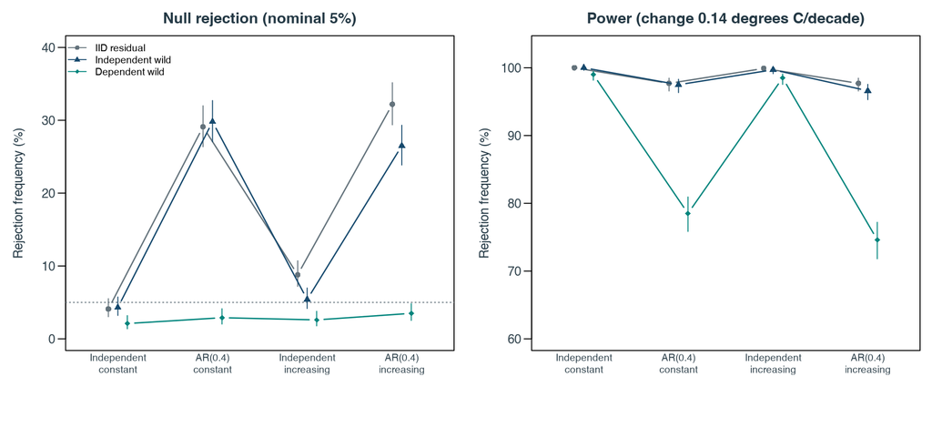

Size and power; vertical lines are Wilson intervals for simulation frequencies.

```r
plot_pair("simulation_results", function() {
    par(mfrow = c(1, 2), mar = c(5.2, 4.4, 2.4, 0.8), mgp = c(2.7, 0.7, 0), las = 1,
        col.axis = axis_colour, col.lab = label_colour,
        col.main = label_colour, cex = 0.8)
    cols <- c(gray, navy, teal)
    for (estimand in c("size", "power")) {
        z <- sim[sim$estimand == estimand, ]
        ks <- unique(z$config)
        ylim <- if (estimand == "size")
            c(0, 40)
        else c(60, 103)
        plot(1, 1, type = "n", xlim = c(0.6, 4.4), ylim = ylim, xaxt = "n", xlab = "", ylab = "Rejection frequency (%)",
            main = ifelse(estimand == "size", "Null rejection (nominal 5%)", "Power (change 0.14 degrees C/decade)"))
        axis(1, at = 1:4, labels = c("Independent\nconstant", "AR(0.4)\nconstant", "Independent\nincreasing",
            "AR(0.4)\nincreasing"), tick = FALSE, cex.axis = 0.8)
        if (estimand == "size")
            abline(h = 5, lty = 3, col = gray)
        for (j in 1:3) {
            zz <- z[z$method == c("iid", "wild", "dwb")[j], ]
            xx <- (1:4) + (j - 2) * 0.1
            lines(xx, 100 * zz$rejection_rate, type = "b", pch = 15 + j, col = cols[j], lwd = 1.4)
            segments(xx, 100 * zz$lower_95, xx, 100 * zz$upper_95, col = cols[j])
        }
        if (estimand == "size")
            legend("topleft", c("IID residual", "Independent wild", "Dependent wild"), col = cols,
                pch = 16:18, lty = 1, bty = "n", cex = 0.8)
    }
}, 10, 4.6)

knitr::include_graphics(file.path(artifact_root, "figures/simulation_results.png"))
```

```r
uncertainty_table <- data.frame(
  Configuration = sim$config, Quantity = sim$estimand,
  Procedure = unname(method_names[sim$method]), Rejections = sim$rejections,
  Frequency_percent = 100 * sim$rejection_rate,
  MC_SE_percentage_points = 100 * sim$mc_se,
  Wilson_lower_percent = 100 * sim$lower_95,
  Wilson_upper_percent = 100 * sim$upper_95
)
knitr::kable(uncertainty_table, digits = 2,
             caption = "Monte Carlo uncertainty for all 24 procedure–scenario combinations")
```

Monte Carlo uncertainty for all 24 procedure–scenario combinations

| Configuration | Quantity | Procedure | Rejections | Frequency_percent | MC_SE_percentage_points | Wilson_lower_percent | Wilson_upper_percent |
| --- | --- | --- | --- | --- | --- | --- | --- |
| 1 | size | IID residual | 41 | 4.1 | 0.63 | 3.04 | 5.51 |
| 1 | size | Independent wild | 43 | 4.3 | 0.64 | 3.21 | 5.74 |
| 1 | size | Dependent wild | 21 | 2.1 | 0.45 | 1.38 | 3.19 |
| 2 | power | IID residual | 1000 | 100.0 | 0.00 | 99.62 | 100.00 |
| 2 | power | Independent wild | 1000 | 100.0 | 0.00 | 99.62 | 100.00 |
| 2 | power | Dependent wild | 990 | 99.0 | 0.31 | 98.17 | 99.46 |
| 3 | size | IID residual | 291 | 29.1 | 1.44 | 26.37 | 31.99 |
| 3 | size | Independent wild | 298 | 29.8 | 1.45 | 27.05 | 32.71 |
| 3 | size | Dependent wild | 29 | 2.9 | 0.53 | 2.03 | 4.13 |
| 4 | power | IID residual | 977 | 97.7 | 0.47 | 96.57 | 98.46 |
| 4 | power | Independent wild | 975 | 97.5 | 0.49 | 96.34 | 98.30 |
| 4 | power | Dependent wild | 785 | 78.5 | 1.30 | 75.85 | 80.93 |
| 5 | size | IID residual | 88 | 8.8 | 0.90 | 7.20 | 10.72 |
| 5 | size | Independent wild | 54 | 5.4 | 0.71 | 4.16 | 6.98 |
| 5 | size | Dependent wild | 26 | 2.6 | 0.50 | 1.78 | 3.78 |
| 6 | power | IID residual | 999 | 99.9 | 0.10 | 99.44 | 99.98 |
| 6 | power | Independent wild | 997 | 99.7 | 0.17 | 99.12 | 99.90 |
| 6 | power | Dependent wild | 985 | 98.5 | 0.38 | 97.54 | 99.09 |
| 7 | size | IID residual | 322 | 32.2 | 1.48 | 29.38 | 35.16 |
| 7 | size | Independent wild | 265 | 26.5 | 1.40 | 23.86 | 29.32 |
| 7 | size | Dependent wild | 35 | 3.5 | 0.58 | 2.53 | 4.83 |
| 8 | power | IID residual | 977 | 97.7 | 0.47 | 96.57 | 98.46 |
| 8 | power | Independent wild | 966 | 96.6 | 0.57 | 95.29 | 97.56 |
| 8 | power | Dependent wild | 746 | 74.6 | 1.38 | 71.81 | 77.20 |

The simulation supports retaining dependence in station inference, but it does not prove that the empirical DWB p-value is conservative. It covers Gaussian innovations, one sample size, one reasonably strong central kink and one DWB bandwidth. It does not evaluate missingness, weak or multiple breaks, alternative dependence models or confidence-interval coverage. Those limits temper direct transfer to the irregular empirical record.

# 6 Conclusion

The Geneva record from 1753 to 2013 shows a positive average linear trend of 0.0337 °C per decade, but a single straight line is not an adequate description of it. The residuals of the linear model are positively autocorrelated (Monte Carlo Durbin–Watson p = 0.0002), while there is no evidence of a trend in the residual variance (Breusch–Pagan p = 0.5183). Part of this dependence reflects low-frequency movements that one slope cannot capture.

A continuous broken trend fits best with a kink at 1851 and reduces the residual sum of squares by 12.53%. It describes the record as a slightly declining trend before the break (-0.0525 °C per decade) followed by warming of 0.0887 °C per decade. The selected year coincides with the coldest year in the record, but excluding that year or the post-gap observations leaves the kink in the mid-nineteenth century, a timing consistent with the end of the Little Ice Age in the Alps.

The evidence that the trend actually changed is moderate. The primary dependent wild bootstrap rejects the no-break null at the 5% level (p = 0.0331), but its p-value rises with the bandwidth to 0.0541 at $\ell=12$. Bootstrap procedures that ignore serial dependence reject much more strongly, but their p-values are not credible given the Section 3 diagnostics. Conditional on the broken-trend model, the pre-break slope is not distinguishable from zero, while the post-break slope is positive under both interval types.

The simulation study shows that independent-error bootstraps over-reject substantially when errors are autocorrelated, whereas the DWB keeps size at or below the nominal level at the cost of lower power. This supports the choice of the DWB for this station, although it does not prove that the empirical DWB p-value is conservative.

In answer to the research question, the Geneva record indicates warming since the mid-nineteenth century of about 0.89 °C per century; a single linear trend understates this warming by averaging it with an earlier cooler phase; and there is moderate, bandwidth-sensitive statistical evidence for a change in the trend. The main limitations are the missing years 1981–2009, station history beyond what homogenisation corrects, the restriction to a single break and a single dependence model, and the absence of a coverage study for the confidence intervals.

# Appendix A: Computational validation

The checks below are executable rather than asserted. They compare the optimised break search with brute-force OLS, reconstruct both interval types from the stored bootstrap draws, verify the finite-replication p-value corrections, reconstruct every simulation rejection frequency and Wilson interval, and replay one complete dataset from each of the eight simulation scenarios. All functions used are defined in this document, and the checks write only to its working folder.

## A.1 Section 3 computations

These checks verify that the 1850 centring and mean-year centring give identical fitted lines and slopes, that the complete supplied sample is retained, that an independent QR projection reproduces all 9,999 draws for both DW definitions, and that the BP statistic agrees with its one-regressor squared-correlation identity.

```r
original_data <- read.csv(file.path(project_root, "Station08.csv"))
stopifnot(identical(dat$Year, original_data$Year),
          identical(dat$Temperature, original_data$Temperature),
          n == 226L, length(missing_years) == 35L, nrow(gap_table) == 5L)
centered_model <- lm(Temperature ~ I((Year - mean(Year)) / 10), data = dat)
stopifnot(max(abs(fitted(centered_model) - fitted(trend_model))) < 1e-10,
          abs(coef(centered_model)[2] - beta1_hat) < 1e-12,
          abs(coef(centered_model)[1] + beta1_hat * (1850 - mean(dat$Year)) / 10 - beta0_hat) < 1e-12)

set.seed(master_seed)
Z_check <- matrix(rnorm(n * B), nrow = n)
Q_check <- qr.Q(qr(model.matrix(trend_model)))
E_check <- Z_check - Q_check %*% crossprod(Q_check, Z_check)
dw_replayed <- colSums((E_check[-1, , drop = FALSE] -
                        E_check[-n, , drop = FALSE])^2) / colSums(E_check^2)
dw_gap_replayed <- colSums((E_check[valid_pairs + 1L, , drop = FALSE] -
                            E_check[valid_pairs, , drop = FALSE])^2) / colSums(E_check^2)
stopifnot(max(abs(dw_replayed - d_sim)) < 1e-10,
          max(abs(dw_gap_replayed - d_sim_gap)) < 1e-10,
          abs(n * cor(dat$residual_sq, dat$t)^2 - BP_stat) < 1e-12)
part1_checks <- c(
  "PASS: all supplied rows, five gaps and 35 missing years are retained",
  "PASS: year-1850 and mean-year parameterizations have identical fitted lines and slopes",
  "PASS: independent QR projection reproduces both 9,999-draw DW reference distributions",
  "PASS: BP agrees with the one-regressor squared-correlation identity"
)
write_csv(dw_results, "tables/dw_comparison.csv")
writeLines(part1_checks, "outputs/part1_validation.txt")
cat(paste(part1_checks, collapse = "\n"), "\n")
```

```
## PASS: all supplied rows, five gaps and 35 missing years are retained
## PASS: year-1850 and mean-year parameterizations have identical fitted lines and slopes
## PASS: independent QR projection reproduces both 9,999-draw DW reference distributions
## PASS: BP agrees with the one-regressor squared-correlation identity
```

## A.2 Break search, intervals and simulation

```r
checks <- character()
pass <- function(text) {
  checks <<- c(checks, paste("PASS:", text))
  cat(tail(checks, 1L), "\n")
}
station <- read.csv(file.path(project_root, "Station08.csv"))
stopifnot(nrow(station) == 226L, !anyNA(station),
          !anyDuplicated(station$Year), all(diff(station$Year) > 0))
y <- station$Temperature
D <- prepare_design(station$Year)
fitted_break <- fit_break(y, D)
x <- D$x
rss_grid <- sapply(D$index, function(k)
  deviance(lm(y ~ x + I(pmax(0, x - x[k])))))
rss_null <- deviance(lm(y ~ x))
stopifnot(abs(fitted_break$F - (rss_null - min(rss_grid))) < 1e-9,
          fitted_break$index == D$index[which.min(rss_grid)],
          max(abs(fitted_break$fitted - fitted(lm(y ~ x +
            I(pmax(0, x - x[fitted_break$index])))))) < 1e-9)
pass("optimized break search agrees with independent brute-force OLS and fitted values")
```

```
## PASS: optimized break search agrees with independent brute-force OLS and fitted values
```

```r
set.seed(320926)
for (method in c("iid", "wild", "dwb")) {
  errors <- bootstrap_errors(fitted_break$null_residuals, D$year, 7L, method, 6, 2)
  projected <- break_statistics(errors, D)$F
  brute <- vapply(seq_len(ncol(errors)), function(b) {
    ystar <- fitted_break$null_fitted + errors[, b]
    rss0 <- deviance(lm(ystar ~ x))
    rss1 <- min(sapply(D$index, function(k)
      deviance(lm(ystar ~ x + I(pmax(0, x - x[k]))))))
    rss0 - rss1
  }, numeric(1L))
  stopifnot(max(abs(projected - brute)) < 1e-8)
}
pass("all 21 bootstrap checks reproduce full null-generated-series OLS statistics")
```

```
## PASS: all 21 bootstrap checks reproduce full null-generated-series OLS statistics
```

```r
ci <- read.csv("tables/confidence_intervals.csv")
ci_draws <- read.csv("tables/ci_draws.csv")
stopifnot(nrow(ci_draws) == 4999L, nrow(ci) == 4L, !anyNA(ci_draws),
          all(ci$B == 4999L), all(ci$lower <= ci$upper),
          all(ci_draws$year %in% D$year[D$index]))
for (parameter in c("pre", "post")) {
  pc <- ci[ci$parameter == parameter & ci$type == "percentile", ]
  pt <- ci[ci$parameter == parameter & ci$type == "percentile_t", ]
  draws <- ci_draws[[parameter]]
  ses <- ci_draws[[paste0("se_", parameter)]]
  stopifnot(all(ses > 0), all(is.finite(ses)))
  percentile <- quantile(draws, c(.025, .975), type = 7, names = FALSE)
  tstar <- (draws - pt$estimate) / ses
  studentized <- pt$estimate - pt$hac_se *
    quantile(tstar, c(.975, .025), type = 7, names = FALSE)
  stopifnot(max(abs(percentile - c(pc$lower, pc$upper))) < 1e-10,
            max(abs(studentized - c(pt$lower, pt$upper))) < 1e-10)
}
pass("percentile and percentile-t intervals recompute from all 4,999 stored refits")
```

```
## PASS: percentile and percentile-t intervals recompute from all 4,999 stored refits
```

```r
bt <- read.csv("tables/bootstrap_tests.csv")
stopifnot(nrow(bt) == 5L, all(bt$B == 9999L),
          all(abs(bt$statistic - fitted_break$F) < 1e-8),
          all(abs(bt$p_value - (1 + bt$exceedances) / (bt$B + 1)) < 1e-12))
pass("all reported empirical p-values follow the finite-replication correction")
```

```
## PASS: all reported empirical p-values follow the finite-replication correction
```

```r
simulation <- readRDS("work/simulation/simulation_results.rds")
raw <- simulation$raw
summary <- read.csv("tables/simulation_summary.csv")
stopifnot(nrow(raw) == 8000L, nrow(summary) == 24L, !anyNA(raw),
          all(table(raw$config) == 1000L), all(summary$M == 1000L),
          all(summary$B == 499L), all(summary$n == 226L),
          abs(simulation$settings$sigma - sqrt(fitted_break$RSS1 / 223)) < 1e-12)
for (s in seq_len(8L)) {
  one <- raw[raw$config == s, ]
  stopifnot(identical(sort(as.integer(one$replication)), seq_len(1000L)),
            all(one$replicate_seed == 20260926L + s * 100000L + one$replication))
  for (method in c("iid", "wild", "dwb")) {
    values <- one[[paste0(method, "_p")]]
    stopifnot(all(values >= 1 / 500 & values <= 1),
              all(abs(500 * values - round(500 * values)) < 1e-8))
    row <- summary[summary$config == s & summary$method == method, ]
    count <- sum(values <= .05)
    rate <- count / 1000
    interval <- wilson_interval(count, 1000)
    stopifnot(row$rejections == count, abs(row$rejection_rate - rate) < 1e-12,
      abs(row$mc_se - sqrt(rate * (1 - rate) / 1000)) < 1e-12,
      max(abs(c(row$lower_95, row$upper_95) - interval)) < 1e-12)
  }
}
pass("all 8,000 replications, 24 rejection rates, MC standard errors and Wilson intervals are consistent")
```

```
## PASS: all 8,000 replications, 24 rejection rates, MC standard errors and Wilson intervals are consistent
```

```r
# Replay one observation from every scenario, independently of worker scheduling.
Ds <- prepare_design(seq_len(226L))
for (s in seq_len(8L)) {
  row <- raw[raw$config == s & raw$replication == 1000L, ]
  set.seed(row$replicate_seed)
  ys <- simulate_broken_trend(Ds, row$delta, row$rho, row$heteroskedastic,
                              simulation$settings$sigma)
  result <- bootstrap_break(ys, Ds, B = 499L)
  stopifnot(abs(result$observed$F - row$F) < 1e-10)
  for (method in c("iid", "wild", "dwb"))
    stopifnot(abs(result$results[[method]]$p_value - row[[paste0(method, "_p")]]) < 1e-12)
}
pass("recorded seeds reproduce one complete replication from every simulation scenario")
```

```
## PASS: recorded seeds reproduce one complete replication from every simulation scenario
```

```r
writeLines(checks, "outputs/validation.txt")
cat("All checks passed. Saved outputs/validation.txt.\n")
```

```
## All checks passed. Saved outputs/validation.txt.
```

# Appendix B: Random seeds and session information

The Section 3 Monte Carlo test and its replay in Appendix A use seed 20260926. The empirical IID residual, independent wild and primary DWB tests use the master seed `20260926` plus 101, 102 and 103. The bandwidth checks at three and twelve years use the master seed plus 203 and 212; the additional grid bandwidths use master plus 200. The slope intervals use the master seed plus 301. Simulation dataset $m$ in scenario $c$ uses `20260926 + 100000*c + m`, independently of worker scheduling.

# Appendix C: Choice of reference year

The time index is $t=(\mathrm{Year}-1850)/10$; the division by ten reports slopes per decade. The reference year 1850 was chosen because it lies next to the estimated break date. The intercept of the linear model is then the fitted temperature in 1850, and, since the estimated break (1851) does not precede 1850, the intercept of the broken-trend model is also its fitted temperature in 1850. The two intercepts are thus directly comparable at 1850. The fitted level at the estimated turning point is instead $\widehat\alpha+\widehat\beta(\widehat T_1-1850)/10$.

Any other reference year, such as the sample mean, would change only the intercept. Fitted values, residuals, slopes, the RSS, the break search and all test statistics are invariant, as verified in Appendix A.1. Centring at the sample mean would minimise the classical OLS variance of the intercept, but no inference in this report concerns the intercept. Because 1850 was chosen with knowledge of the Section 4 estimate, the choice is purely presentational; although 1850 is also a common pre-industrial reference year in climate assessments, it is not used here in that sense.

# Appendix D: Effect of data gaps on the analysis

| Component | Effect of gaps | Approach retained or refined |
| --- | --- | --- |
| Exploratory and residual time plots | Observed lines must not imply data inside gaps | Lines are grouped by contiguous years; the largest gap is shaded |
| OLS estimates | Calendar spacing is represented, but coverage and missingness can matter | Retain $(\mathrm{Year}-1850)/10$ and the complete supplied sample |
| Residual ACF | Observation lags and calendar lags differ | Display both; calendar grid contains `NA` for absent years |
| Variance smooth | Its curve inside a gap is unsupported by observations there | Retain the descriptive smooth with an explicit limitation |
| QQ plot | Time order is absent from its construction | Treat it as a marginal descriptive comparison, not proof of Gaussianity |
| DW statistic and Monte Carlo | The specified formula uses observation adjacency | Primary specified statistic plus separately calibrated calendar-adjacent sensitivity |
| BP test | Algebra uses actual time; dependence qualifies its reference | Retain $nR^2$ and nominal $\chi^2_1$, with cautious non-rejection language |
| Section 4 bootstrap | Dependence should use actual calendar gaps | DWB multipliers depend on elapsed years; every sample repeats the date search |
| Overall interpretation | Missing decades and metadata limit conclusions | No inference about an unobserved trajectory, global change or physical cause |